# GrowthAnalysis_Basia

Now run the second model to look at differences by pop or trt on beta and gamma. Start with the linear only model.

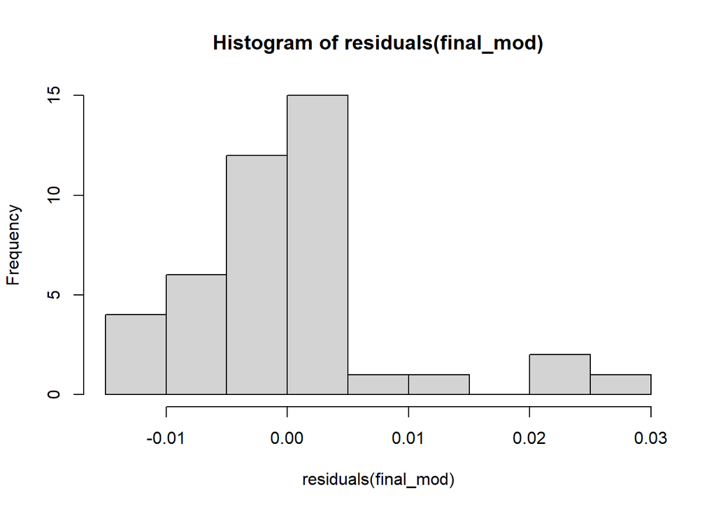

```r
# step 2 model for linear step 1
final_mod <- lm(Beta ~ Trt * Pop, data = slopes, contrasts = list(Trt=contr.sum, Pop = contr.sum))
hist(residuals(final_mod))
```

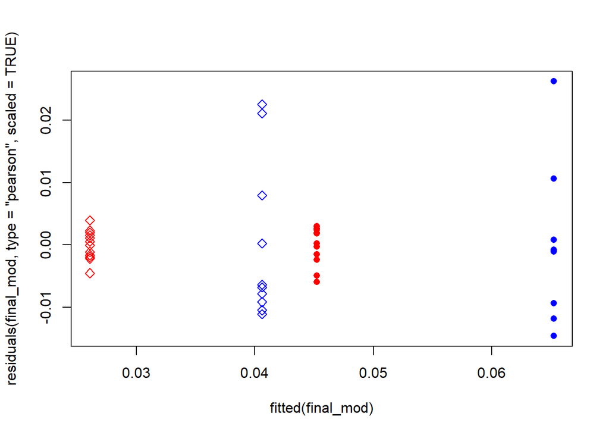

```r
plot(fitted(final_mod), residuals(final_mod, type = "pearson", scaled = TRUE),
       col = c("red", "blue")[as.numeric(slopes$Pop)],
       pch = c(16, 5)[as.numeric(slopes$Trt)])
```

```r
# I think this is better
summary(final_mod)
```

```
##
## Call:
## lm(formula = Beta ~ Trt * Pop, data = slopes, contrasts = list(Trt = contr.sum,
##     Pop = contr.sum))
##
## Residuals:
##        Min         1Q     Median         3Q        Max
## -0.0146231 -0.0048506 -0.0001486  0.0022238  0.0262616
##
## Coefficients:
##              Estimate Std. Error t value Pr(>|t|)
## (Intercept)  0.044284   0.001367  32.395  < 2e-16 ***
## Trt1         0.010955   0.001367   8.014 1.09e-09 ***
## Pop1        -0.008642   0.001367  -6.322 2.06e-07 ***
## Trt1:Pop1   -0.001367   0.001367  -1.000    0.324
## ---
## Signif. codes:  0 '***' 0.001 '**' 0.01 '*' 0.05 '.' 0.1 ' ' 1
##
## Residual standard error: 0.008737 on 38 degrees of freedom
## Multiple R-squared:  0.7214, Adjusted R-squared:  0.6994
## F-statistic:  32.8 on 3 and 38 DF,  p-value: 1.227e-10
```

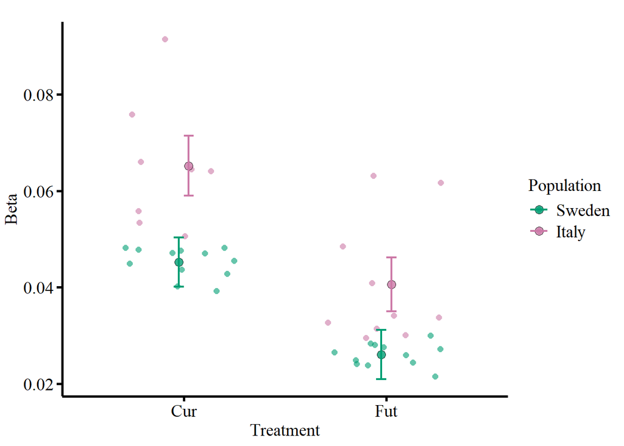

```r
# estimated marginal means for plotting
slope_means <- as.data.frame(emmeans(final_mod, specs = c("Trt", "Pop")))

# plot. mean is the predicted value.
ggplot(data = slopes, aes(y = Beta, x = Trt))+
  geom_point(aes(col = Pop), alpha = 0.6, shape = 16, position = position_jitter(width = .3, height = 0), size = 2)+
  geom_point(data = slope_means, aes(x = Trt, y = emmean, fill = Pop),position = position_dodge(width = 0.1), alpha = 0.8, shape = 21, size = 3)+ # big point for pop means
  geom_errorbar(data = slope_means, aes(x = Trt, y = emmean, ymin=lower.CL, ymax = upper.CL, col = Pop),position = position_dodge(width = 0.1), width = 0.1, size = 0.8, show.legend = TRUE)+
  #geom_line(data = slope_means, aes(group = Pop, col = Pop), size = 1)+
  labs(x = "Treatment")+
  scale_color_manual(name = "Population",
                     labels = c("Sweden", "Italy"),
                     values = c("#009E73", "#CC79A7"))+
  scale_fill_manual(name = "Population",
                     labels = c("Sweden", "Italy"),
                     values = c("#009E73", "#CC79A7"))
```

```r
# without log, Italy has two low outliers in Cur that don't appear when log transformed.
```

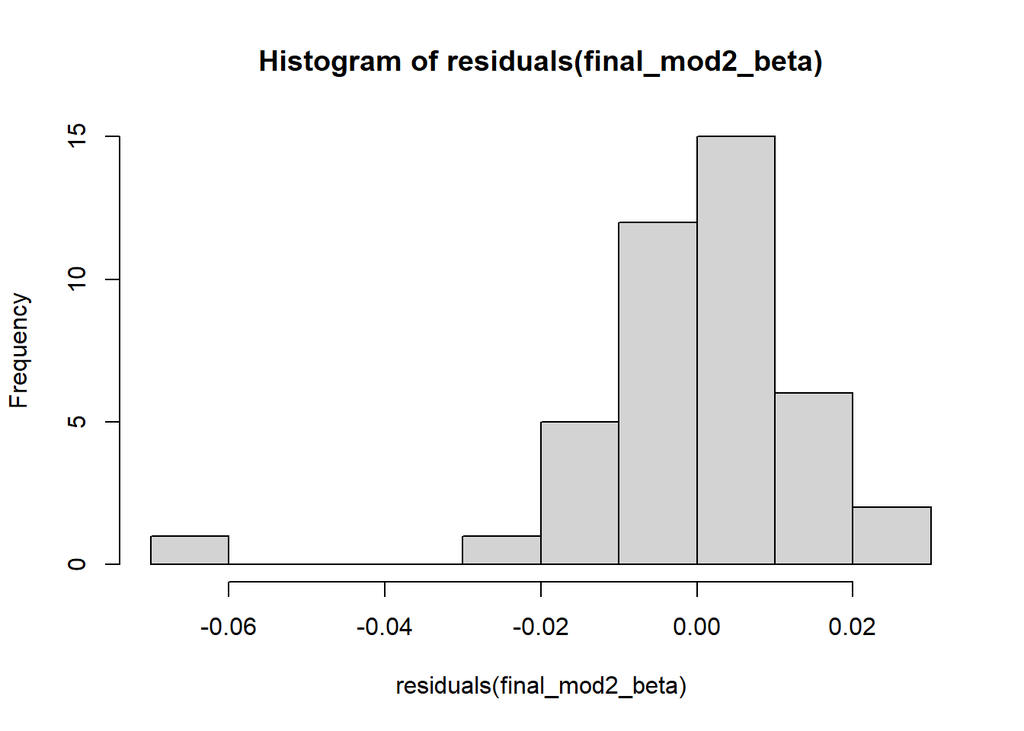

```r
final_mod2_beta <- lm(Beta ~ Trt * Pop, data = slopes2, contrasts = list(Trt=contr.sum, Pop = contr.sum))
hist(residuals(final_mod2_beta))
```

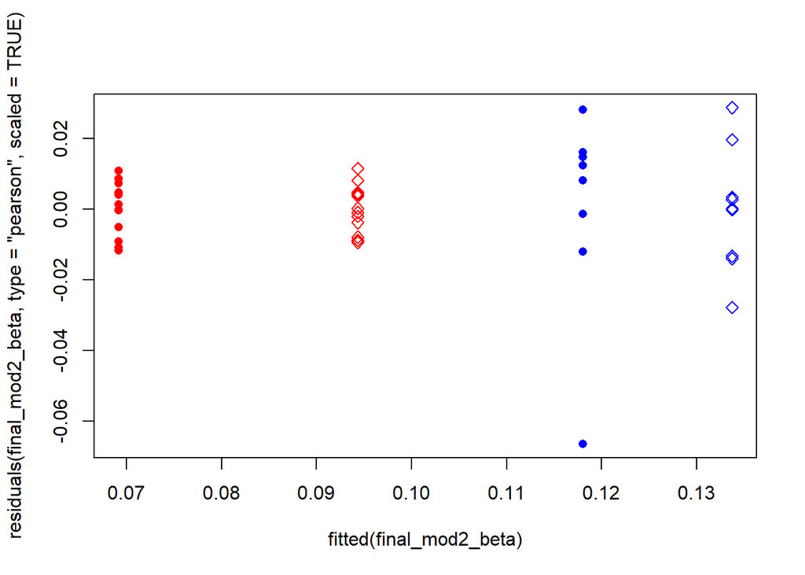

```r
plot(fitted(final_mod2_beta), residuals(final_mod2_beta, type = "pearson", scaled = TRUE),
       col = c("red", "blue")[as.numeric(slopes2$Pop)],
       pch = c(16, 5)[as.numeric(slopes2$Trt)])
```

```r
summary(final_mod2_beta)
```

```
##
## Call:
## lm(formula = Beta ~ Trt * Pop, data = slopes2, contrasts = list(Trt = contr.sum,
##     Pop = contr.sum))
##
## Residuals:
##       Min        1Q    Median        3Q       Max
## -0.066396 -0.007172  0.000245  0.007924  0.028761
##
## Coefficients:
##              Estimate Std. Error t value Pr(>|t|)
## (Intercept)  0.103807   0.002484  41.785  < 2e-16 ***
## Trt1        -0.010207   0.002484  -4.109 0.000204 ***
## Pop1        -0.022048   0.002484  -8.875 8.45e-11 ***
## Trt1:Pop1   -0.002364   0.002484  -0.951 0.347415
## ---
## Signif. codes:  0 '***' 0.001 '**' 0.01 '*' 0.05 '.' 0.1 ' ' 1
##
## Residual standard error: 0.01588 on 38 degrees of freedom
## Multiple R-squared:  0.7283, Adjusted R-squared:  0.7069
## F-statistic: 33.96 on 3 and 38 DF,  p-value: 7.627e-11
```

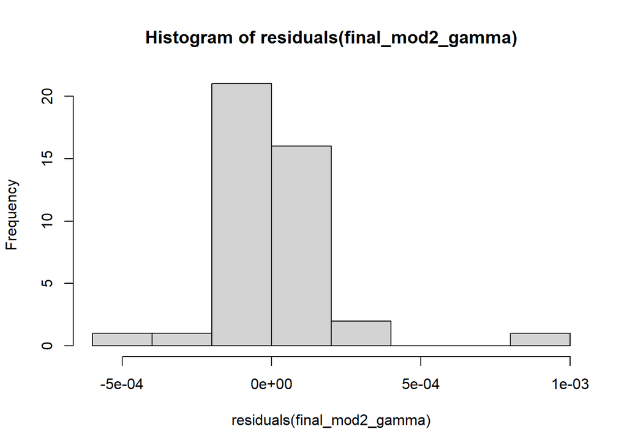

```r
# all the standard errors for each term are identical
final_mod2_gamma <- lm(gamma ~ Trt * Pop, data = slopes2, contrasts = list(Trt=contr.sum, Pop = contr.sum))
hist(residuals(final_mod2_gamma))
```

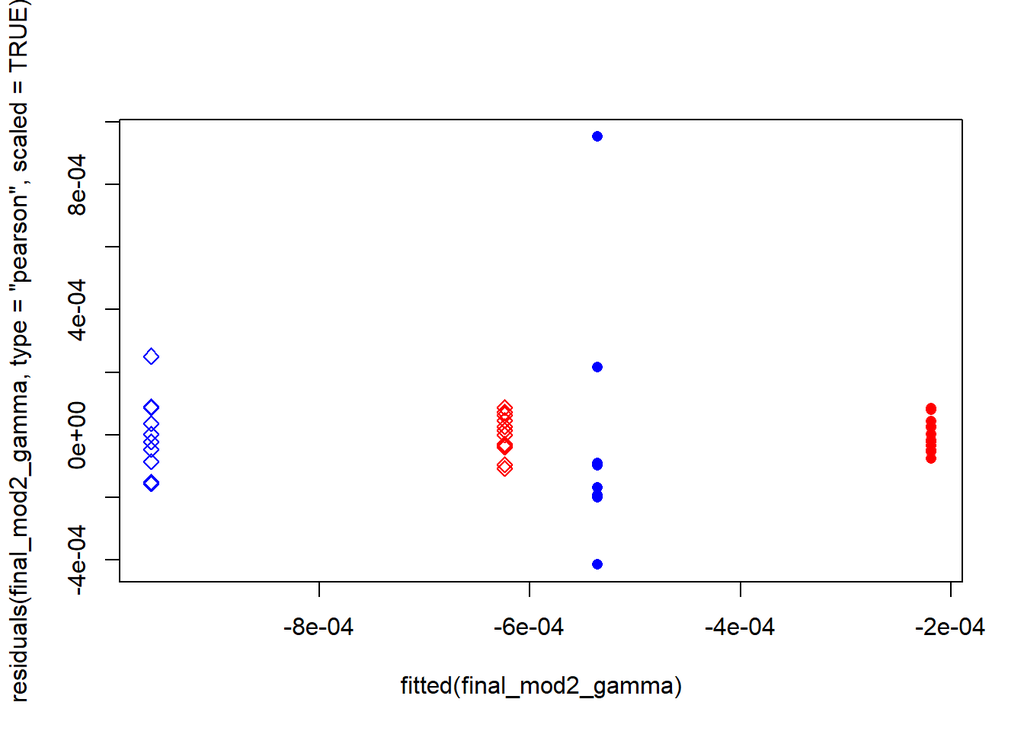

```r
plot(fitted(final_mod2_gamma), residuals(final_mod2_gamma, type = "pearson", scaled = TRUE),
       col = c("red", "blue")[as.numeric(slopes2$Pop)],
       pch = c(16, 5)[as.numeric(slopes2$Trt)])
```

```r
summary(final_mod2_gamma)
```

```
##
## Call:
## lm(formula = gamma ~ Trt * Pop, data = slopes2, contrasts = list(Trt = contr.sum,
##     Pop = contr.sum))
##
## Residuals:
##        Min         1Q     Median         3Q        Max
## -4.152e-04 -8.330e-05 -2.106e-05  4.515e-05  9.526e-04
##
## Coefficients:
##               Estimate Std. Error t value Pr(>|t|)
## (Intercept) -5.849e-04  3.069e-05 -19.059  < 2e-16 ***
## Trt1         2.074e-04  3.069e-05   6.758 5.23e-08 ***
## Pop1         1.632e-04  3.069e-05   5.317 4.91e-06 ***
## Trt1:Pop1   -4.664e-06  3.069e-05  -0.152     0.88
## ---
## Signif. codes:  0 '***' 0.001 '**' 0.01 '*' 0.05 '.' 0.1 ' ' 1
##
## Residual standard error: 0.0001961 on 38 degrees of freedom
## Multiple R-squared:  0.6757, Adjusted R-squared:   0.65
## F-statistic: 26.39 on 3 and 38 DF,  p-value: 2.135e-09
```

```r
final_mod2_int <- lm(intercept ~ Trt * Pop, data = slopes2, contrasts = list(Trt=contr.sum, Pop = contr.sum))

# estimated marginal means for plotting
slope2_means <- as.data.frame(emmeans(final_mod2_beta, specs = c("Trt", "Pop")))
slope2_gammas <- as.data.frame(emmeans(final_mod2_gamma, specs = c("Trt", "Pop")))
slope2_intercepts <- as.data.frame(emmeans(final_mod2_int, specs = c("Trt", "Pop")))

# plot. mean is the predicted value... that is good and makes sense?
beta_leafarea <- ggplot(data = slopes2, aes(y = Beta, x = Trt))+
  geom_point(aes(col = Pop, fill = Pop, shape = Pop), alpha = 0.6, position = position_jitter(width = .3, height = 0), size = 2)+
  geom_errorbar(data = slope2_means, aes(x = Trt, y = emmean, ymin=lower.CL, ymax = upper.CL, col = Pop),position = position_dodge(width = 0.5), width = 0.3, size = 0.8, show.legend = FALSE)+
  geom_point(data = slope2_means, aes(x = Trt, y = emmean, fill = Pop, shape = Pop),position = position_dodge(width = 0.5), size = 3)+ # big point for pop means
  labs(x = "Treatment", y = expression(paste("Leaf Area :  ", beta)))+
  scale_color_manual(name = "Population",
                     labels = c("Sweden", "Italy"),
                     values = c("#009E73", "#CC79A7"))+
  scale_fill_manual(name = "Population",
                     labels = c("Sweden", "Italy"),
                     values = c("#009E73", "#CC79A7"))+
    scale_shape_manual(name = "Population",
                     labels = c("Sweden", "Italy"),
                     values = c(24, 21))

gamma_leafarea <- ggplot(data = slopes2, aes(y = gamma, x = Trt))+
  geom_point(aes(col = Pop, fill = Pop, shape = Pop), alpha = 0.6, position = position_jitter(width = .3, height = 0), size = 2)+
  geom_errorbar(data = slope2_gammas, aes(x = Trt, y = emmean, ymin=lower.CL, ymax = upper.CL, col = Pop), position = position_dodge(width = 0.5), width = 0.3, size = 0.8, show.legend = FALSE)+
  geom_point(data = slope2_gammas, aes(x = Trt, y = emmean, fill = Pop, shape = Pop), position = position_dodge(width = 0.5), size = 3)+ # big point for pop means
  labs(x = "Treatment", y = expression(paste("Leaf Area :  ", gamma)))+
  scale_color_manual(name = "Population",
                     labels = c("Sweden", "Italy"),
                     values = c("#009E73", "#CC79A7"))+
  scale_fill_manual(name = "Population",
                     labels = c("Sweden", "Italy"),
                     values = c("#009E73", "#CC79A7"))+
  scale_shape_manual(name = "Population",
                     labels = c("Sweden", "Italy"),
                     values = c(24, 21))
```

Plot for quadratic fit with model prediction lines

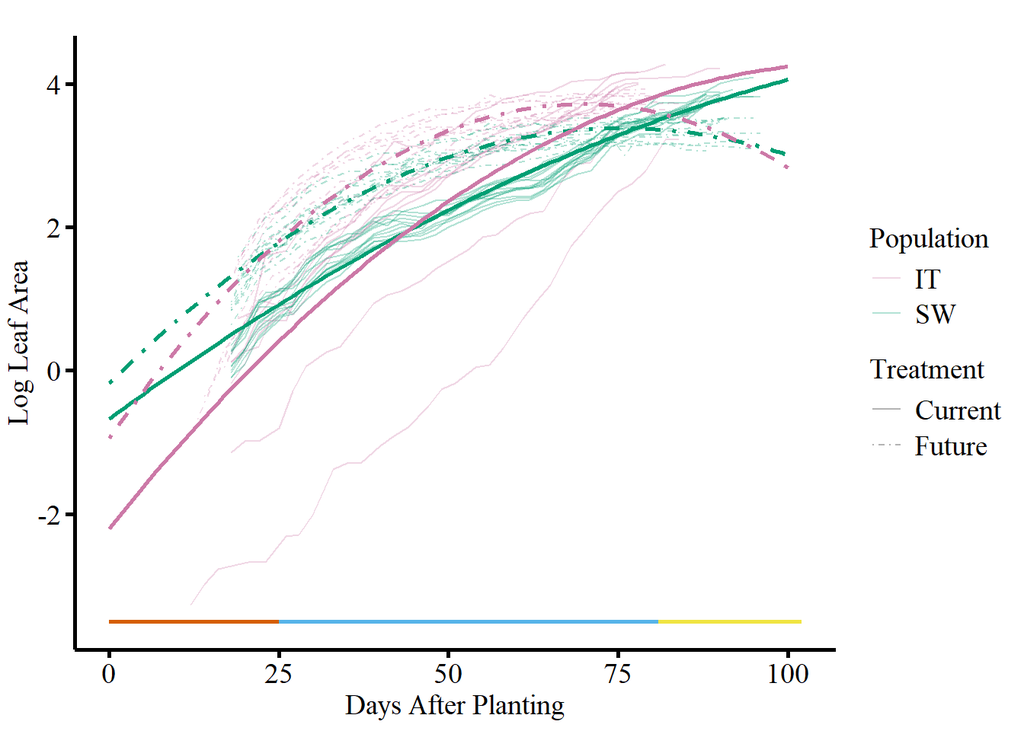

```r
#would need to create a custom function for each line
RosAreaTime$log_area <- log(RosAreaTime$LeafArea)


trends_leafarea <- ggplot(data = RosAreaTime, aes(x = DaysFromEmergence, y = log_area))+
  geom_line(aes(group = grp, col = Population, linetype = Trt), size = 0.4, alpha = 0.3, show.legend = TRUE)+
  geom_function(fun = function(x) slope2_intercepts$emmean[1] + slope2_means$emmean[1]*x + slope2_gammas$emmean[1]*x^2, colour = "#009E73", linetype = "solid", xlim=c(0, 100), size = 0.9)+ # Cur SW
geom_function(fun = function(x) slope2_intercepts$emmean[2] + slope2_means$emmean[2]*x + slope2_gammas$emmean[2]*x^2, colour = "#009E73", linetype = "dotdash", xlim=c(0, 100), size = 0.9)+ # Fut SW
geom_function(fun = function(x) slope2_intercepts$emmean[3] + slope2_means$emmean[3]*x + slope2_gammas$emmean[3]*x^2, colour = "#CC79A7", linetype = "solid", xlim=c(0, 100), size = 0.9)+ # Cur IT
geom_function(fun = function(x) slope2_intercepts$emmean[4] + slope2_means$emmean[4]*x + slope2_gammas$emmean[4]*x^2, colour = "#CC79A7", linetype = "dotdash", xlim=c(0, 100), size = 0.9)+ # Fut IT
  geom_segment(aes(x = 0, xend = 25, y = -3.5, yend = -3.5), col = "#D55E00", size = 1)+
  geom_segment(aes(x = 25, xend = 81, y = -3.5, yend = -3.5), col = "#56B4E9", size = 1)+
  geom_segment(aes(x = 81, xend = 102, y = -3.5, yend = -3.5), col = "#F0E442", size = 1)+
  labs(x = "Days After Planting", y = "Log Leaf Area")+
  scale_color_manual(name = "Population",
                     labels = c("IT", "SW"),
                     values = c("#CC79A7", "#009E73"))+
  scale_linetype_manual(name = "Treatment",
                        labels = c("Current", "Future"),
                        values = c("solid", "dotdash"))

trends_leafarea
```

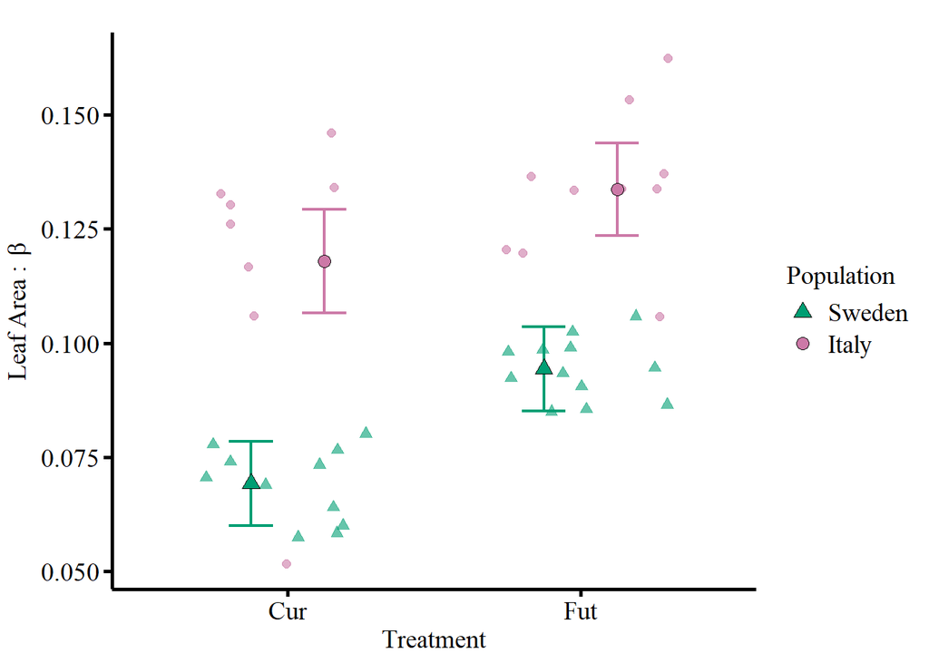

```r
beta_leafarea
```

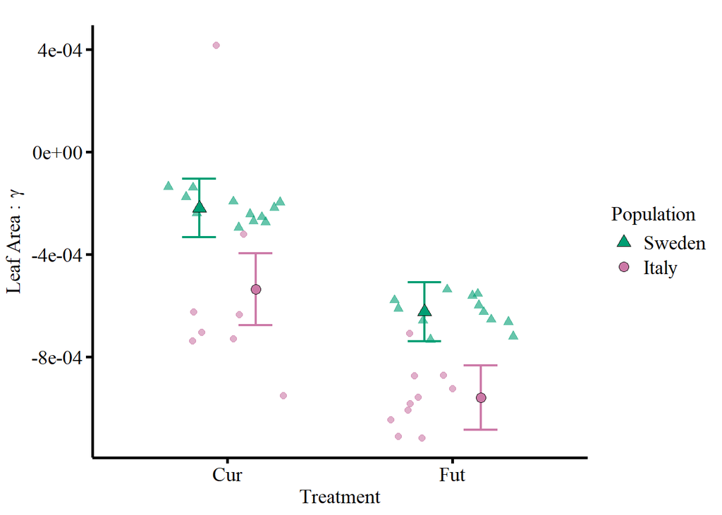

```r
gamma_leafarea
```

### Rosette Leaf Number

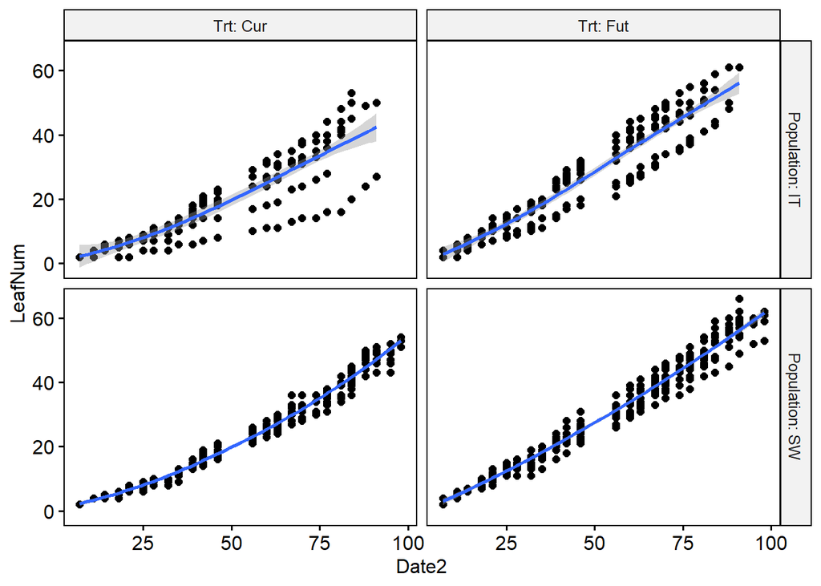

```r
# remove NAs
rosnum <- LeafNumTime[complete.cases(LeafNumTime), ]

# remove zeros
rosnum <- rosnum[!(rosnum$LeafNum == 0), ]

# make geno a factor
rosnum$Geno <- as.factor(rosnum$Geno)
# add log transformed column
rosnum$log_ln <- log(rosnum$LeafNum)


# plot trends by grouping factor
ggscatter(
  rosnum, x = "Date2", y = "LeafNum",
  facet.by  = c("Population", "Trt"),
  short.panel.labs = FALSE
  )+
  stat_smooth(method = "loess", span = 0.9)
```

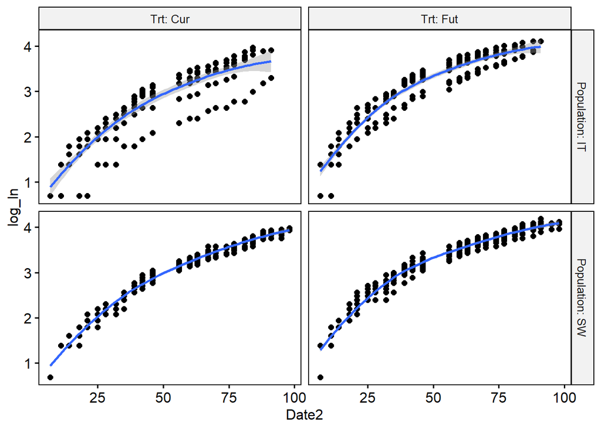

```r
ggscatter(
  rosnum, x = "Date2", y = "log_ln",
  facet.by  = c("Population", "Trt"),
  short.panel.labs = FALSE
  )+
  stat_smooth(method = "loess", span = 0.9)
```

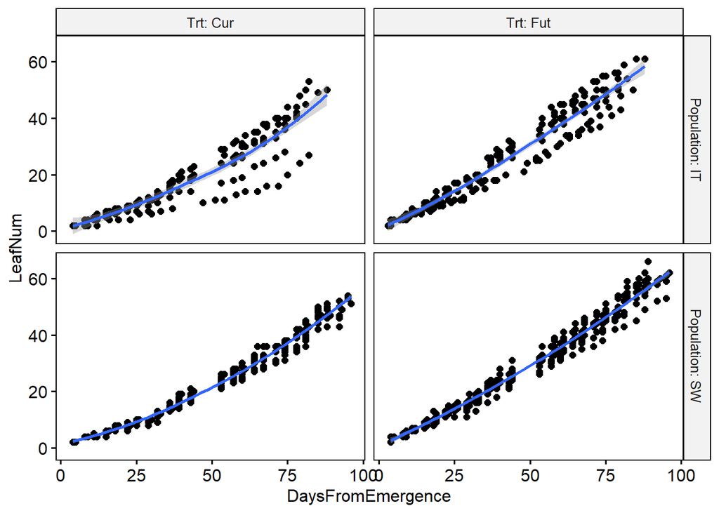

```r
# by Days Since Emergence
ggscatter(
  rosnum, x = "DaysFromEmergence", y = "LeafNum",
  facet.by  = c("Population", "Trt"),
  short.panel.labs = FALSE
  )+
  stat_smooth(method = "loess", span = 0.9)
```

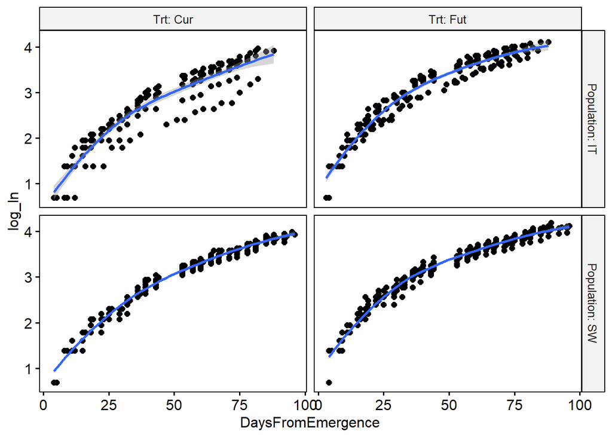

```r
ggscatter(
  rosnum, x = "DaysFromEmergence", y = "log_ln",
  facet.by  = c("Population", "Trt"),
  short.panel.labs = FALSE
  )+
  stat_smooth(method = "loess", span = 0.9)
```

Run models to get growth rate (slopes). Quadratic was added for a better fit, so also need to get gammas.

```r
# add quadratic term, no scaling
rosnum$quad_date <- rosnum$DaysFromEmergence^2
```

```r
# make a list of dataframes where each dataframe is the leaf areas for one genotype
ln_by_geno <- list(rep(NA, times = 44))
genos_ln <- unique(rosnum$Geno)
trts_ln <- unique(rosnum$Trt)

# current
for (i in 1:22){
  ln_by_geno[[i]] <- rosnum[(rosnum$Geno == genos_ln[i]& rosnum$Trt == trts_ln[1]), ]
}
# 102 and 105 again have no data

# fut
for (i in 1:length(genos_ln)){
  ln_by_geno[[22+i]] <- rosnum[(rosnum$Geno == genos_ln[i]& rosnum$Trt == trts_ln[2]), ]
}

ln_by_geno <- ln_by_geno[c(1,3,4,6:44)]
```

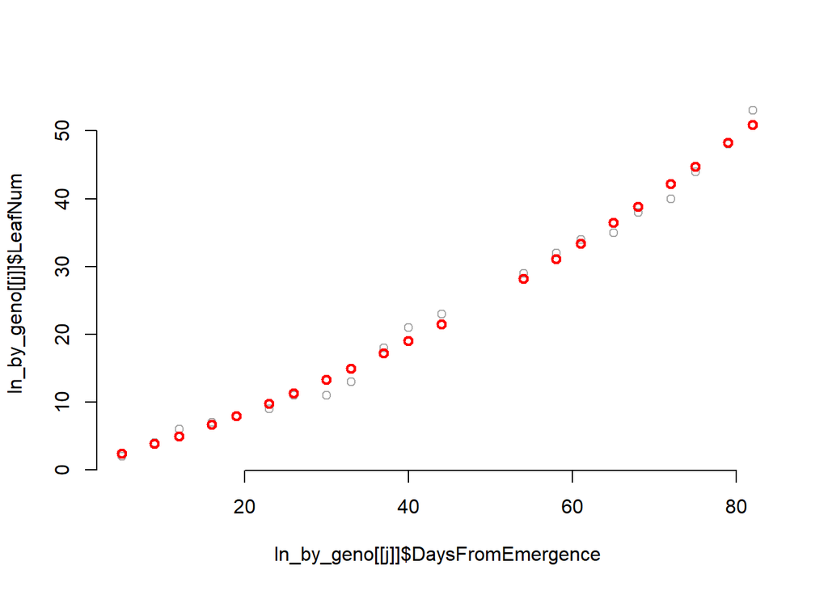

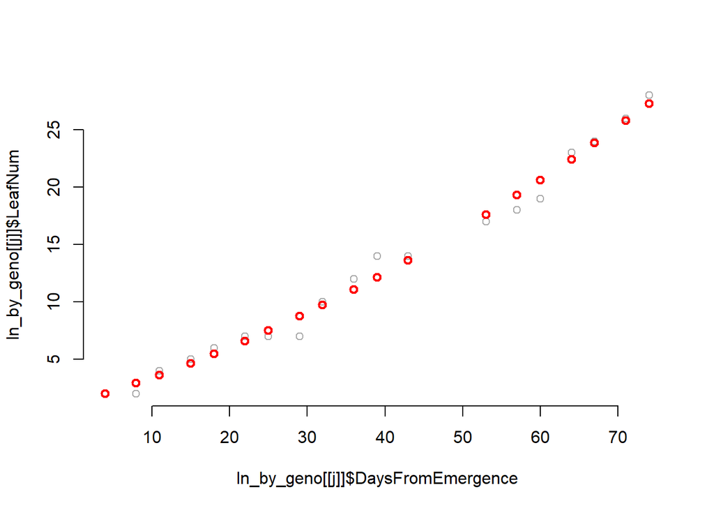

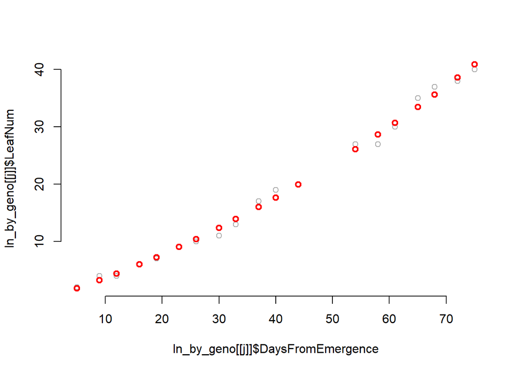

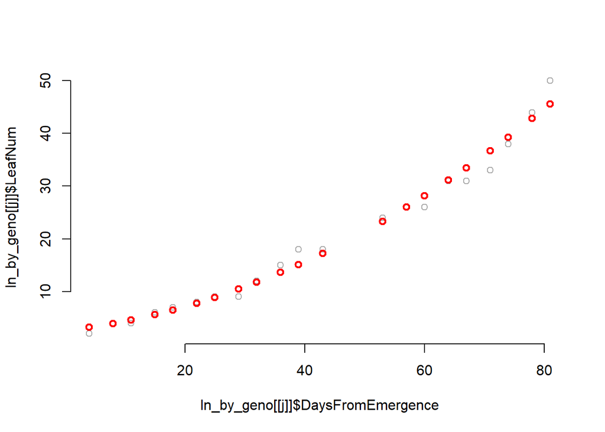

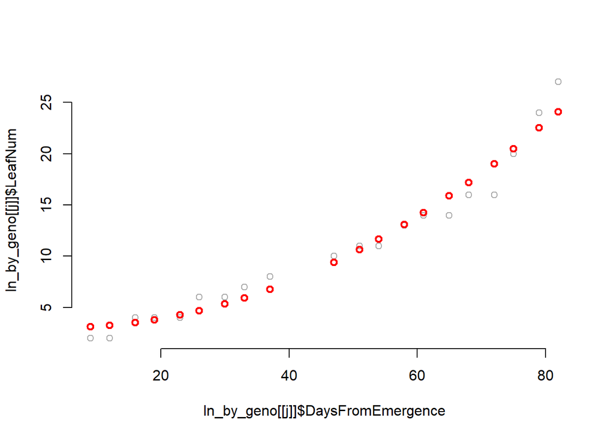

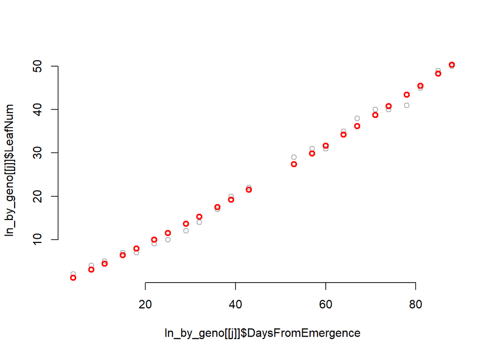

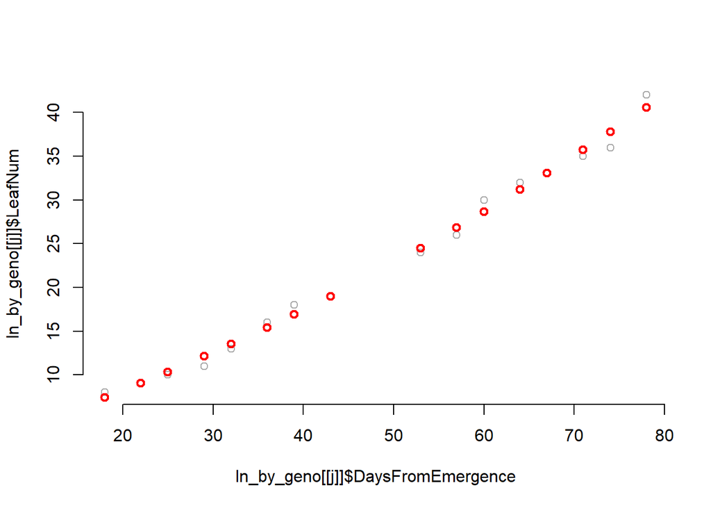

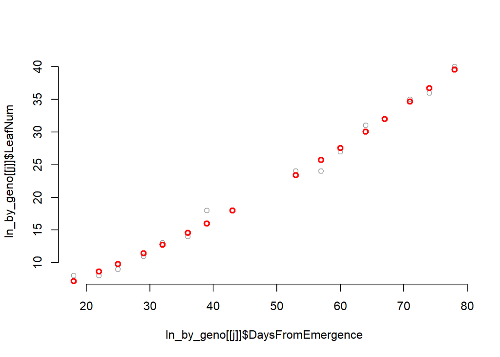

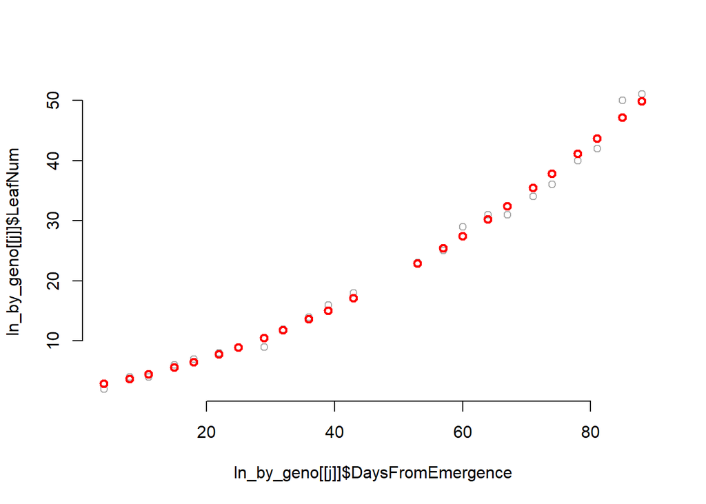

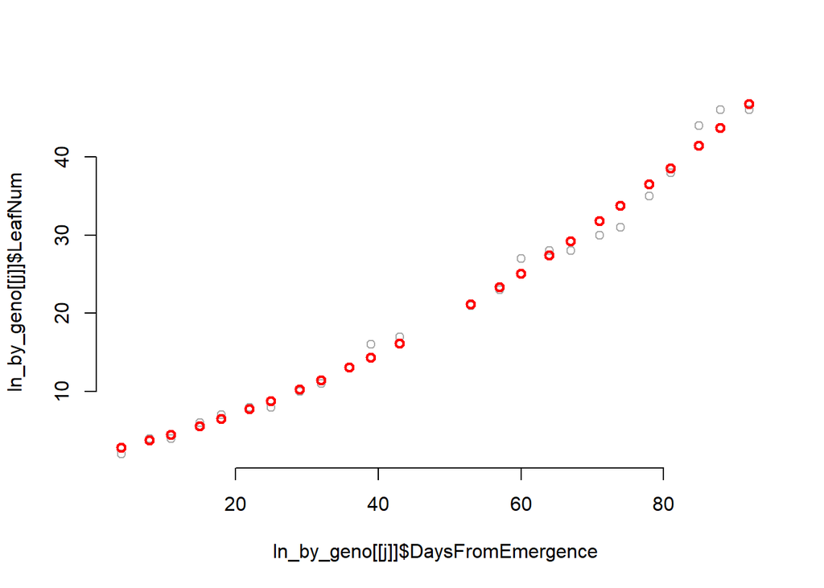

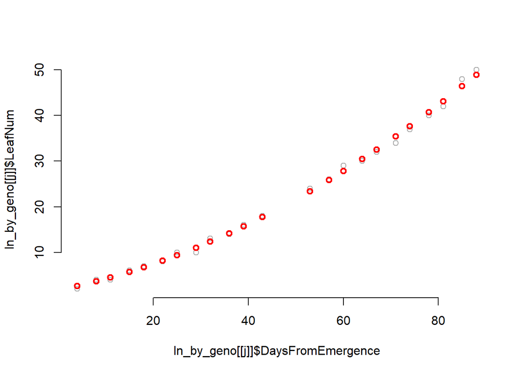

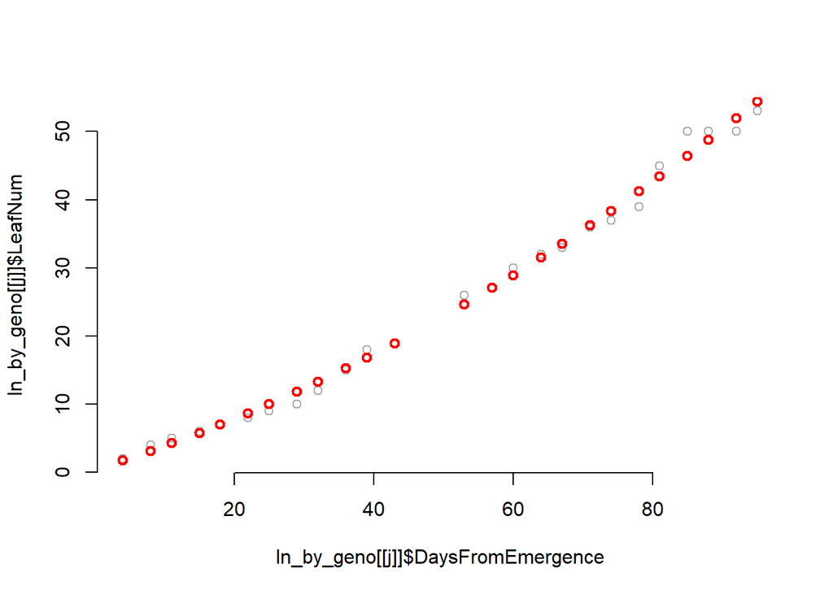

[30 more figures not shown]

```r
# run a model for each item in the ln_by_geno list
slopes_ln <- data.frame(Geno = c(genos[c(1,3,4,6:22)], genos),
                     Trt = as.factor(c(rep("Cur", times = 20), rep("Fut", times = 22))),
                     Beta = rep(NA, times = 42))
slopes_ln$uniqueID <- paste0(slopes_ln$Trt, slopes_ln$Geno )
slopes_ln$Pop <- factor("SW", levels = c("SW", "IT"))
slopes_ln[as.numeric(slopes_ln$Geno) < 11, "Pop" ] <- "IT"

for (j in 1:length(ln_by_geno)){
  tmp <- lm(LeafNum ~ DaysFromEmergence, data = ln_by_geno[[j]])
  # do any of the models fit well?
  #hist(residuals(tmp))
  #plot(fitted(tmp), residuals(tmp, type = "pearson", scaled = TRUE))
  slopes_ln$Beta[j] <- tmp[["coefficients"]][["DaysFromEmergence"]]
  # model data
  modData = tmp$coefficients[1]+ln_by_geno[[j]]$DaysFromEmergence*tmp$coefficients[2]
  ## look at the model-predicted data curve on top of the actual data
  #plot(ln_by_geno[[j]]$DaysFromEmergence, ln_by_geno[[j]]$LeafNum, bty="n", col="darkgray")
  #points(ln_by_geno[[j]]$DaysFromEmergence, modData,col="red",lwd=2)

}

# check quadratic

slopes2_ln <- data.frame(Geno = c(genos[c(1,3,4,6:22)], genos),
                     Trt = as.factor(c(rep("Cur", times = 20), rep("Fut", times = 22))),
                     Beta = rep(NA, times = 42),
                     gamma = rep(NA, times = 42))
slopes2_ln$uniqueID <- paste0(slopes_ln$Trt, slopes_ln$Geno )
slopes2_ln$Pop <- factor("SW", levels = c("SW", "IT"))
slopes2_ln[as.numeric(slopes2_ln$Geno) < 11, "Pop" ] <- "IT"

for (j in 1:length(ln_by_geno)){
  tmp <- lm(LeafNum ~ DaysFromEmergence + quad_date, data = ln_by_geno[[j]])
  # do any of the models fit well?
  #hist(residuals(tmp))
  #plot(fitted(tmp), residuals(tmp, type = "pearson", scaled = TRUE))
  slopes2_ln$Beta[j] <- tmp[["coefficients"]][["DaysFromEmergence"]]
  slopes2_ln$gamma[j] <- tmp[["coefficients"]][["quad_date"]]
  slopes2_ln$intercept[j] <- tmp[["coefficients"]][["(Intercept)"]]
  # model data
  modData = tmp$coefficients[1]+as.numeric(ln_by_geno[[j]]$DaysFromEmergence)*tmp$coefficients[2] + as.numeric(ln_by_geno[[j]]$quad_date)*tmp$coefficients[3]
  ## look at the model-predicted data curve on top of the actual data
  plot(ln_by_geno[[j]]$DaysFromEmergence, ln_by_geno[[j]]$LeafNum, bty="n", col="darkgray")
  points(ln_by_geno[[j]]$DaysFromEmergence, modData,col="red",lwd=2)

}
```

Now run the second model to look at differences by pop or trt on beta and gamma. Start with the linear only model.

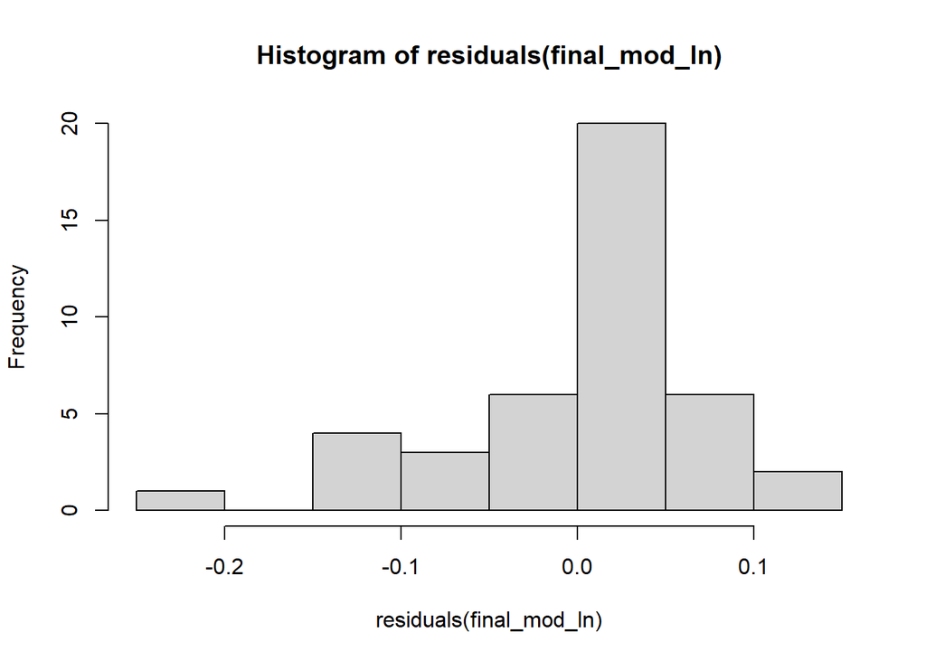

```r
# actual model for linear step 1
final_mod_ln <- lm(Beta ~ Trt * Pop, data = slopes_ln, contrasts = list(Trt=contr.sum, Pop = contr.sum))
hist(residuals(final_mod_ln))
```

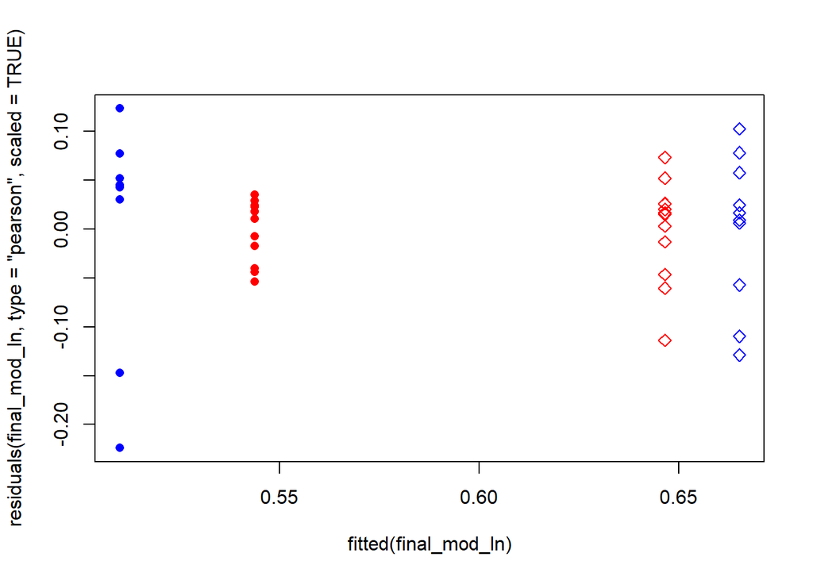

```r
plot(fitted(final_mod_ln), residuals(final_mod_ln, type = "pearson", scaled = TRUE),
       col = c("red", "blue")[as.numeric(slopes_ln$Pop)],
       pch = c(16, 5)[as.numeric(slopes_ln$Trt)])
```

```r
summary(final_mod_ln)
```

```
##
## Call:
## lm(formula = Beta ~ Trt * Pop, data = slopes_ln, contrasts = list(Trt = contr.sum,
##     Pop = contr.sum))
##
## Residuals:
##      Min       1Q   Median       3Q      Max
## -0.22393 -0.03452  0.01747  0.03403  0.12345
##
## Coefficients:
##              Estimate Std. Error t value Pr(>|t|)
## (Intercept)  0.591365   0.011170  52.943  < 2e-16 ***
## Trt1        -0.064401   0.011170  -5.766 1.19e-06 ***
## Pop1         0.003779   0.011170   0.338    0.737
## Trt1:Pop1    0.013109   0.011170   1.174    0.248
## ---
## Signif. codes:  0 '***' 0.001 '**' 0.01 '*' 0.05 '.' 0.1 ' ' 1
##
## Residual standard error: 0.07139 on 38 degrees of freedom
## Multiple R-squared:  0.4674, Adjusted R-squared:  0.4253
## F-statistic: 11.12 on 3 and 38 DF,  p-value: 2.233e-05
```

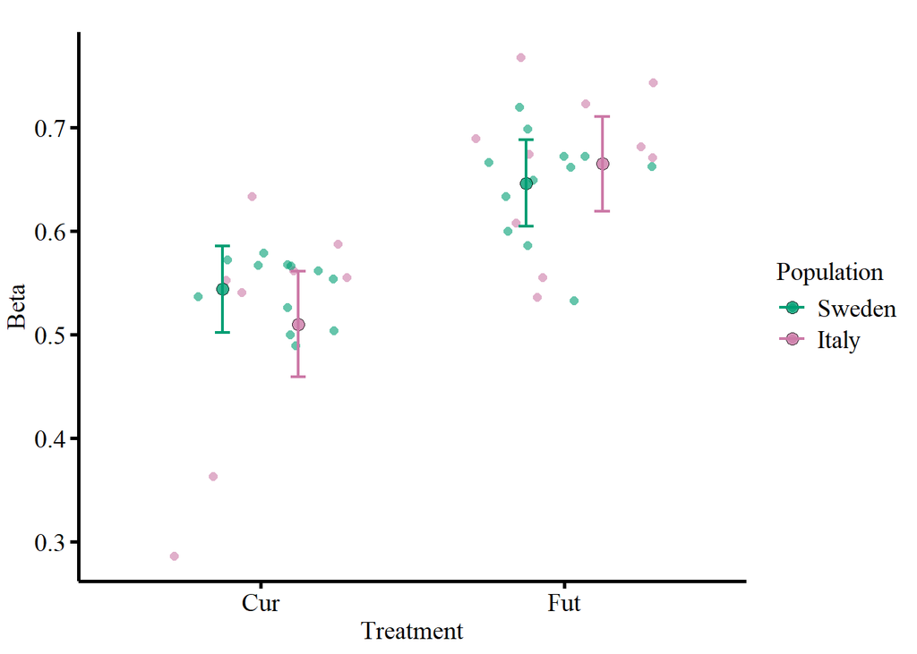

```r
# estimated marginal means for plotting
slope_ln_means <- as.data.frame(emmeans(final_mod_ln, specs = c("Trt", "Pop")))

# plot. mean is the predicted value.
ggplot(data = slopes_ln, aes(y = Beta, x = Trt))+
  geom_point(aes(col = Pop), alpha = 0.6, shape = 16, position = position_jitter(width = .3, height = 0), size = 2)+
  geom_point(data = slope_ln_means, aes(x = Trt, y = emmean, fill = Pop),position = position_dodge(width = 0.5), alpha = 0.8, shape = 21, size = 3)+ # big point for pop means
  geom_errorbar(data = slope_ln_means, aes(x = Trt, y = emmean, ymin=lower.CL, ymax = upper.CL, col = Pop),position = position_dodge(width = 0.5), width = 0.1, size = 0.8, show.legend = TRUE)+
  #geom_line(data = slope_means, aes(group = Pop, col = Pop), size = 1)+
  labs(x = "Treatment")+
  scale_color_manual(name = "Population",
                     labels = c("Sweden", "Italy"),
                     values = c("#009E73", "#CC79A7"))+
  scale_fill_manual(name = "Population",
                     labels = c("Sweden", "Italy"),
                     values = c("#009E73", "#CC79A7"))
```

Now run the second model with the quadratic.

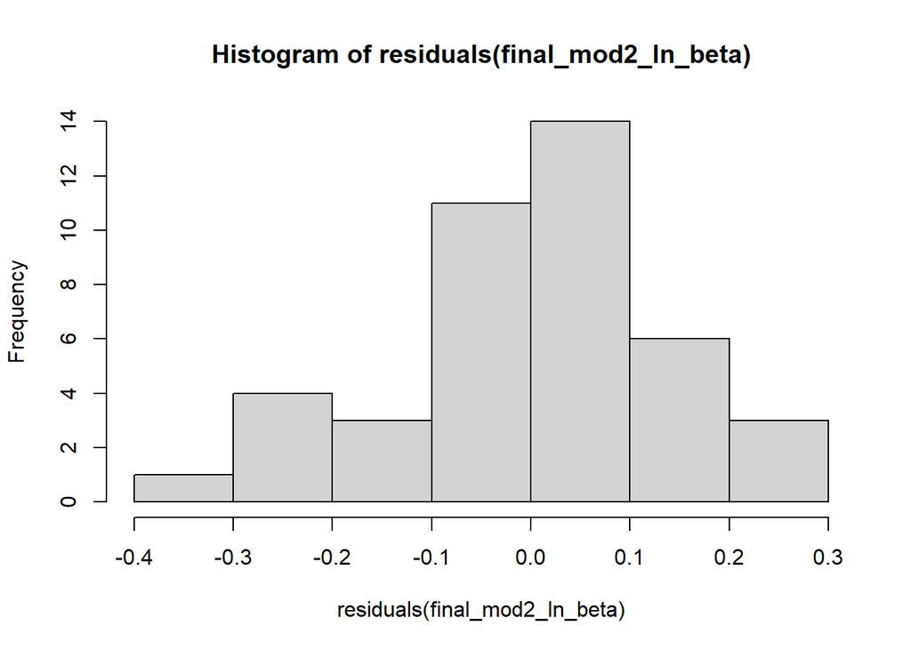

```r
final_mod2_ln_beta <- lm(Beta ~ Trt * Pop, data = slopes2_ln, contrasts = list(Trt=contr.sum, Pop = contr.sum))
hist(residuals(final_mod2_ln_beta))
```

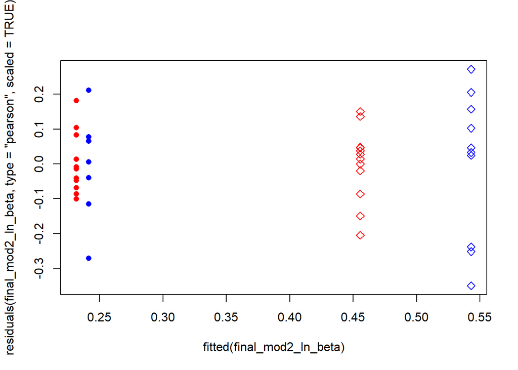

```r
plot(fitted(final_mod2_ln_beta), residuals(final_mod2_ln_beta, type = "pearson", scaled = TRUE),
       col = c("red", "blue")[as.numeric(slopes2_ln$Pop)],
       pch = c(16, 5)[as.numeric(slopes2_ln$Trt)])
```

```r
summary(final_mod2_ln_beta)
```

```
##
## Call:
## lm(formula = Beta ~ Trt * Pop, data = slopes2_ln, contrasts = list(Trt = contr.sum,
##     Pop = contr.sum))
##
## Residuals:
##      Min       1Q   Median       3Q      Max
## -0.34942 -0.06315  0.01357  0.07449  0.27139
##
## Coefficients:
##             Estimate Std. Error t value Pr(>|t|)
## (Intercept)  0.36781    0.02185  16.832  < 2e-16 ***
## Trt1        -0.13135    0.02185  -6.011  5.5e-07 ***
## Pop1        -0.02426    0.02185  -1.110    0.274
## Trt1:Pop1    0.01944    0.02185   0.889    0.379
## ---
## Signif. codes:  0 '***' 0.001 '**' 0.01 '*' 0.05 '.' 0.1 ' ' 1
##
## Residual standard error: 0.1397 on 38 degrees of freedom
## Multiple R-squared:  0.5025, Adjusted R-squared:  0.4632
## F-statistic: 12.79 on 3 and 38 DF,  p-value: 6.316e-06
```

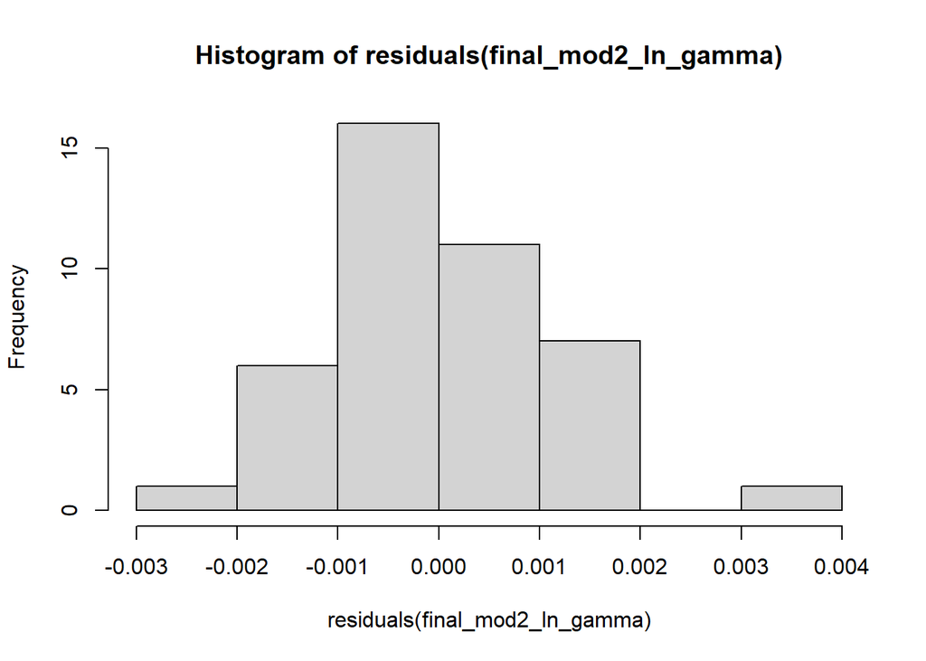

```r
# all the standard errors for each term are identical
final_mod2_ln_gamma <- lm(gamma ~ Trt * Pop, data = slopes2_ln, contrasts = list(Trt=contr.sum, Pop = contr.sum))
hist(residuals(final_mod2_ln_gamma))
```

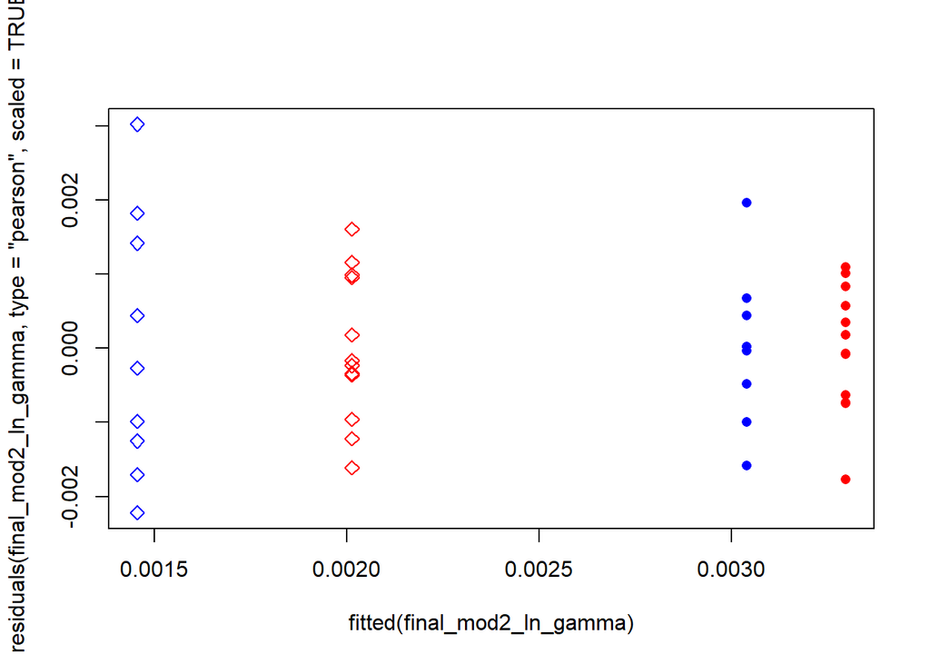

```r
plot(fitted(final_mod2_ln_gamma), residuals(final_mod2_ln_gamma, type = "pearson", scaled = TRUE),
       col = c("red", "blue")[as.numeric(slopes2_ln$Pop)],
       pch = c(16, 5)[as.numeric(slopes2_ln$Trt)])
```

```r
summary(final_mod2_ln_gamma)
```

```
##
## Call:
## lm(formula = gamma ~ Trt * Pop, data = slopes2_ln, contrasts = list(Trt = contr.sum,
##     Pop = contr.sum))
##
## Residuals:
##        Min         1Q     Median         3Q        Max
## -0.0022200 -0.0007427 -0.0000750  0.0007955  0.0030211
##
## Coefficients:
##               Estimate Std. Error t value Pr(>|t|)
## (Intercept)  2.450e-03  1.841e-04  13.311 6.94e-16 ***
## Trt1         7.169e-04  1.841e-04   3.895 0.000385 ***
## Pop1         2.040e-04  1.841e-04   1.108 0.274780
## Trt1:Pop1   -7.526e-05  1.841e-04  -0.409 0.684938
## ---
## Signif. codes:  0 '***' 0.001 '**' 0.01 '*' 0.05 '.' 0.1 ' ' 1
##
## Residual standard error: 0.001176 on 38 degrees of freedom
## Multiple R-squared:  0.3094, Adjusted R-squared:  0.2549
## F-statistic: 5.675 on 3 and 38 DF,  p-value: 0.002589
```

```r
final_mod2_ln_int <- lm(intercept ~ Trt * Pop, data = slopes2_ln, contrasts = list(Trt=contr.sum, Pop = contr.sum))

# estimated marginal means for plotting
slope2_ln_means <- as.data.frame(emmeans(final_mod2_ln_beta, specs = c("Trt", "Pop")))
slope2_ln_gammas <- as.data.frame(emmeans(final_mod2_ln_gamma, specs = c("Trt", "Pop")))
slope2_ln_intercepts <- as.data.frame(emmeans(final_mod2_ln_int, specs = c("Trt", "Pop")))

# plot
beta_leafnum <- ggplot(data = slopes2_ln, aes(y = Beta, x = Trt))+
  geom_point(aes(col = Pop, fill = Pop, shape = Pop), alpha = 0.6, position = position_jitter(width = .3, height = 0), size = 2)+
  geom_errorbar(data = slope2_ln_means, aes(x = Trt, y = emmean, ymin=lower.CL, ymax = upper.CL, col = Pop),position = position_dodge(width = 0.5), width = 0.3, size = 0.8, show.legend = FALSE)+
    geom_point(data = slope2_ln_means, aes(x = Trt, y = emmean, fill = Pop, shape = Pop),position = position_dodge(width = 0.5), size = 3)+ # big point for pop means
  labs(x = "Treatment", y = expression(paste("Leaf Number :  ", beta)))+
  scale_color_manual(name = "Population",
                     labels = c("Sweden", "Italy"),
                     values = c("#009E73", "#CC79A7"))+
  scale_fill_manual(name = "Population",
                     labels = c("Sweden", "Italy"),
                     values = c("#009E73", "#CC79A7"))+
    scale_shape_manual(name = "Population",
                     labels = c("Sweden", "Italy"),
                     values = c(24, 21))

gamma_leafnum <- ggplot(data = slopes2_ln, aes(y = gamma, x = Trt))+
  geom_point(aes(col = Pop, fill = Pop, shape = Pop), alpha = 0.6, position = position_jitter(width = .3, height = 0), size = 2)+
  geom_errorbar(data = slope2_ln_gammas, aes(x = Trt, y = emmean, ymin=lower.CL, ymax = upper.CL, col = Pop),position = position_dodge(width = 0.5), width = 0.3, size = 0.8, show.legend = FALSE)+
    geom_point(data = slope2_ln_gammas, aes(x = Trt, y = emmean, fill = Pop, shape = Pop),position = position_dodge(width = 0.5), size = 3)+ # big point for pop means
  labs(x = "Treatment", y = expression(paste("Leaf Number :  ",gamma)))+
  scale_color_manual(name = "Population",
                     labels = c("Sweden", "Italy"),
                     values = c("#009E73", "#CC79A7"))+
  scale_fill_manual(name = "Population",
                     labels = c("Sweden", "Italy"),
                     values = c("#009E73", "#CC79A7"))+
    scale_shape_manual(name = "Population",
                     labels = c("Sweden", "Italy"),
                     values = c(24, 21))
```

Plot model predictions over raw data

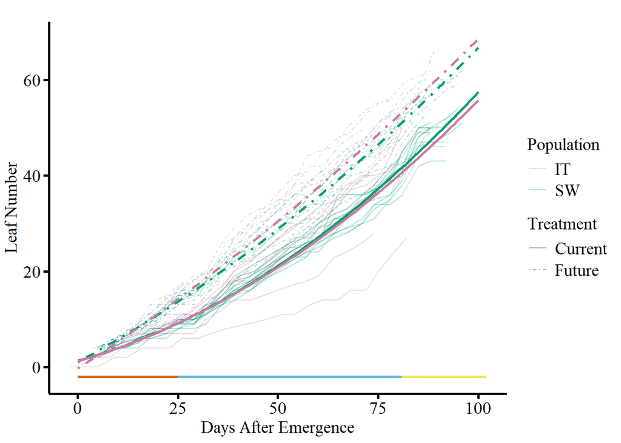

```r
trends_leafnum <- ggplot(data = LeafNumTime, aes(x = DaysFromEmergence, y = LeafNum))+
  geom_line(aes(group = grp, col = Population, linetype = Trt), size = 0.4, alpha = 0.3, show.legend = TRUE)+
  geom_function(fun = function(x) slope2_ln_intercepts$emmean[1] + slope2_ln_means$emmean[1]*x + slope2_ln_gammas$emmean[1]*x^2, colour = "#009E73", linetype = "solid", xlim=c(0, 100), size = 0.9)+ # Cur SW
geom_function(fun = function(x) slope2_ln_intercepts$emmean[2] + slope2_ln_means$emmean[2]*x + slope2_ln_gammas$emmean[2]*x^2, colour = "#009E73", linetype = "dotdash", xlim=c(0, 100), size = 0.9)+ # Fut SW
geom_function(fun = function(x) slope2_ln_intercepts$emmean[3] + slope2_ln_means$emmean[3]*x + slope2_ln_gammas$emmean[3]*x^2, colour = "#CC79A7", linetype = "solid", xlim=c(0, 100), size = 0.9)+ # Cur IT
geom_function(fun = function(x) slope2_ln_intercepts$emmean[4] + slope2_ln_means$emmean[4]*x + slope2_ln_gammas$emmean[4]*x^2, colour = "#CC79A7", linetype = "dotdash", xlim=c(0, 100), size = 0.9)+ # Fut IT
  geom_segment(aes(x = 0, xend = 25, y = -2, yend = -2), col = "#D55E00", size = 1)+
  geom_segment(aes(x = 25, xend = 81, y = -2, yend = -2), col = "#56B4E9", size = 1)+
  geom_segment(aes(x = 81, xend = 102, y = -2, yend = -2), col = "#F0E442", size = 1)+
  labs(x = "Days After Emergence", y = "Leaf Number")+
  scale_color_manual(name = "Population",
                     labels = c("IT", "SW"),
                     values = c("#CC79A7", "#009E73"))+
  scale_linetype_manual(name = "Treatment",
                        labels = c("Current", "Future"),
                        values = c("solid", "dotdash"))

trends_leafnum
```

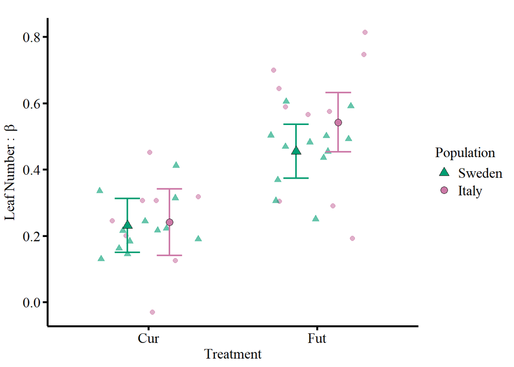

```r
beta_leafnum
```

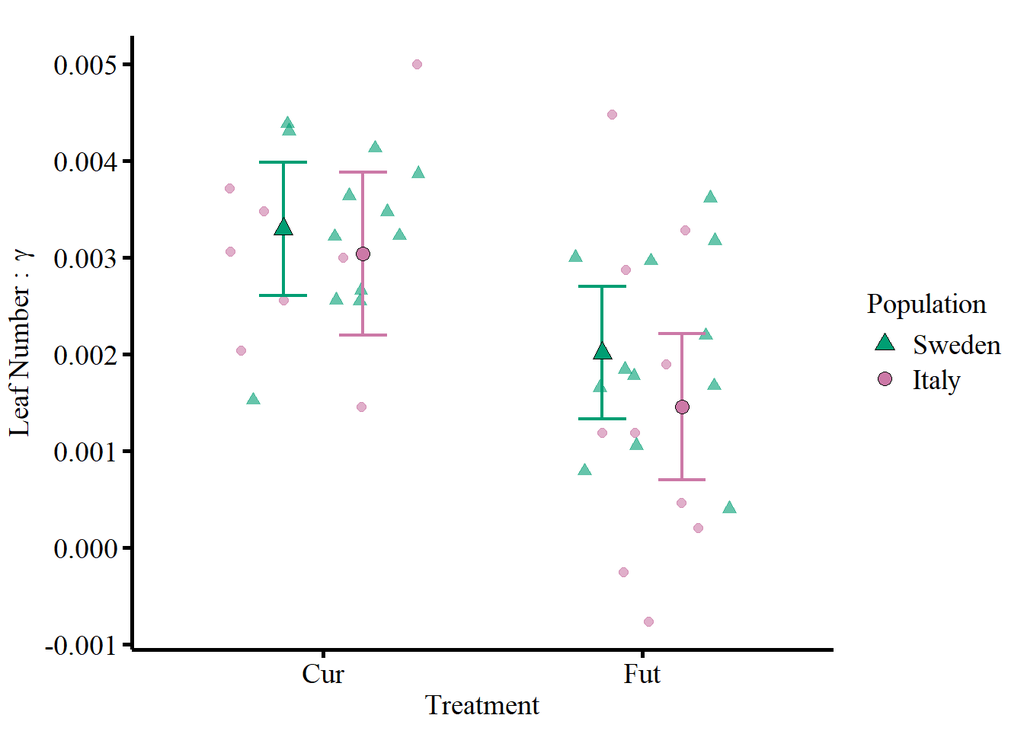

```r
gamma_leafnum
```

### Total Leaf Number

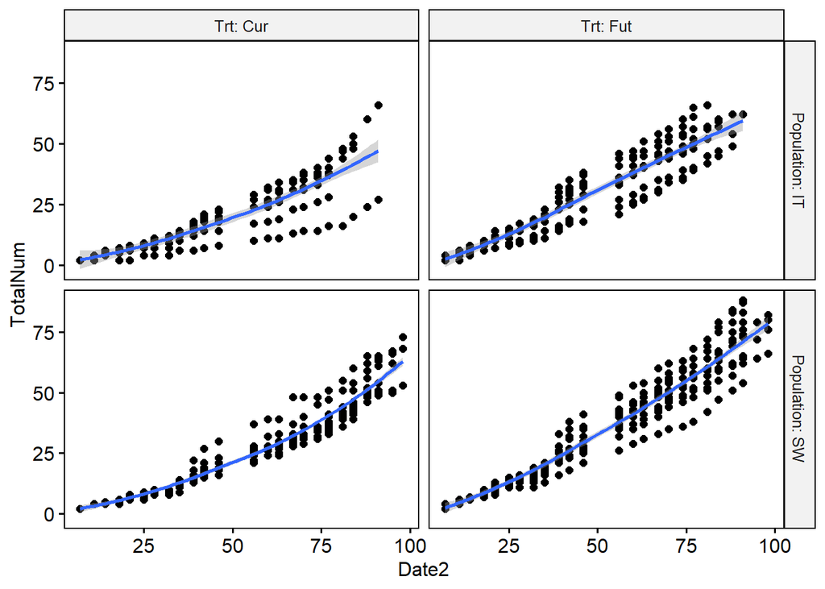

```r
# remove NAs
totnum <- TotalNumTime[complete.cases(TotalNumTime), ]
# remove zeros
totnum <- totnum[!(totnum$TotalNum == 0), ]

# make geno a factor
totnum$Geno <- as.factor(totnum$Geno)

# add log transformed column
totnum$log_tn <- log(totnum$TotalNum)

# plot trends by grouping factor
ggscatter(
  totnum, x = "Date2", y = "TotalNum",
  facet.by  = c("Population", "Trt"),
  short.panel.labs = FALSE
  )+
  stat_smooth(method = "loess", span = 0.9)
```

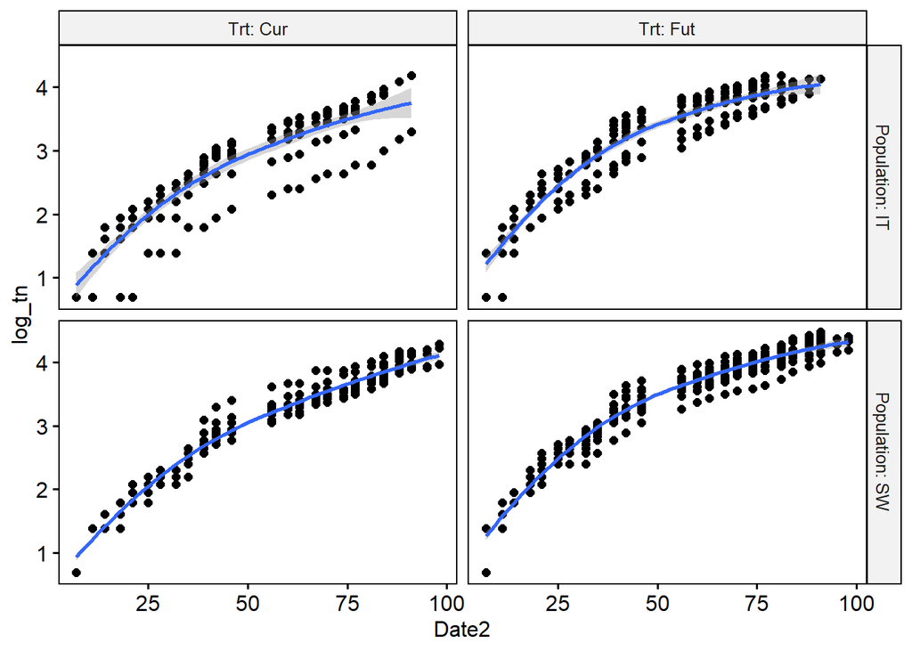

```r
ggscatter(
  totnum, x = "Date2", y = "log_tn",
  facet.by  = c("Population", "Trt"),
  short.panel.labs = FALSE
  )+
  stat_smooth(method = "loess", span = 0.9)
```

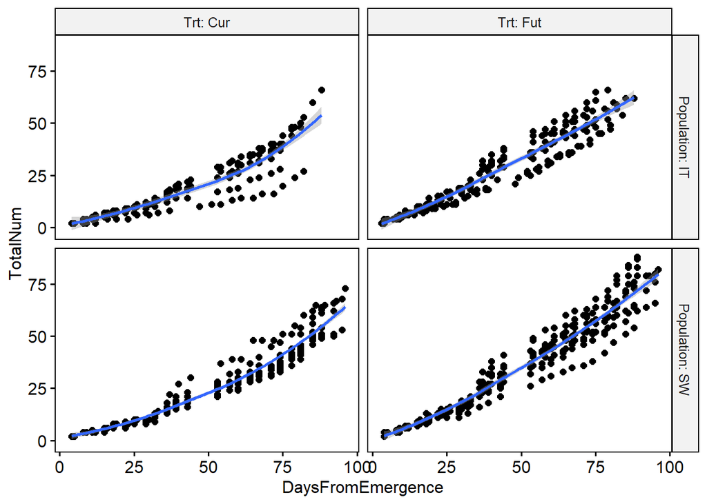

```r
ggscatter(
  totnum, x = "DaysFromEmergence", y = "TotalNum",
  facet.by  = c("Population", "Trt"),
  short.panel.labs = FALSE
  )+
  stat_smooth(method = "loess", span = 0.9)
```

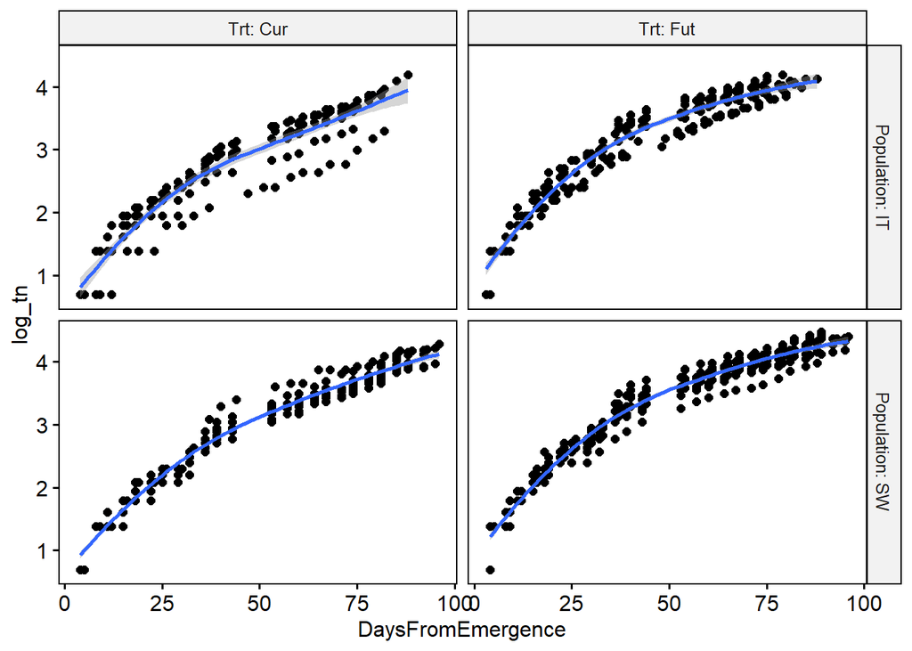

```r
ggscatter(
  totnum, x = "DaysFromEmergence", y = "log_tn",
  facet.by  = c("Population", "Trt"),
  short.panel.labs = FALSE
  )+
  stat_smooth(method = "loess", span = 0.9)
```

Run models to get growth rate (slopes). Quadratic was added for a better fit, so also need to get gammas.

```r
# add quadratic term, no scaling
totnum$quad_date <- totnum$DaysFromEmergence^2
```

```r
# make a list of dataframes where each dataframe is the leaf areas for one genotype
tn_by_geno <- list(rep(NA, times = 44))
genos_tn <- unique(totnum$Geno)
trts_tn <- unique(totnum$Trt)

# current
for (i in 1:22){
  tn_by_geno[[i]] <- totnum[(totnum$Geno == genos_ln[i]& totnum$Trt == trts_ln[1]), ]
}

# future
for (i in 1:length(genos_tn)){
  tn_by_geno[[22+i]] <- totnum[(totnum$Geno == genos_ln[i]& totnum$Trt == trts_ln[2]), ]
}

tn_by_geno <- tn_by_geno[c(1,3,4,6:44)]
```

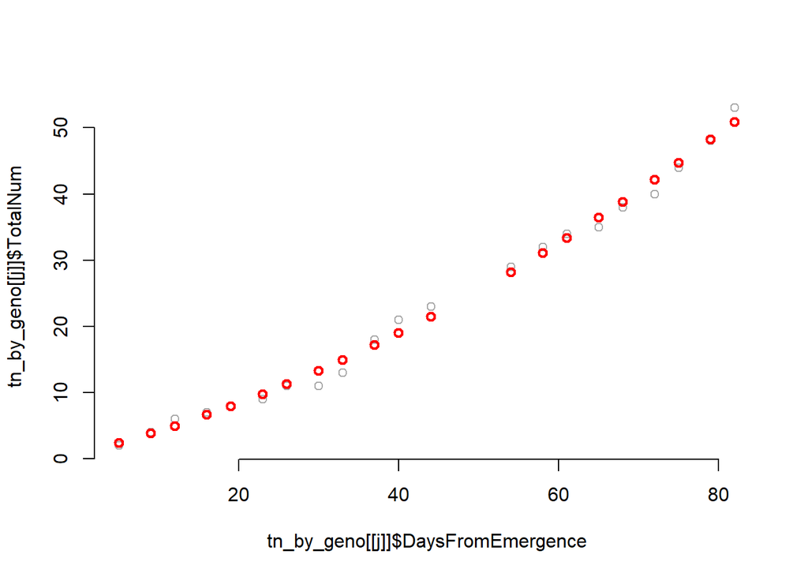

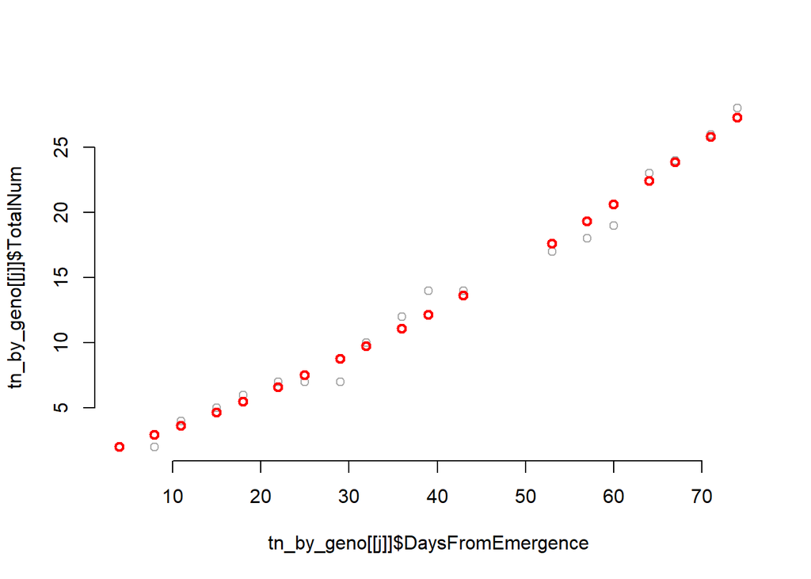

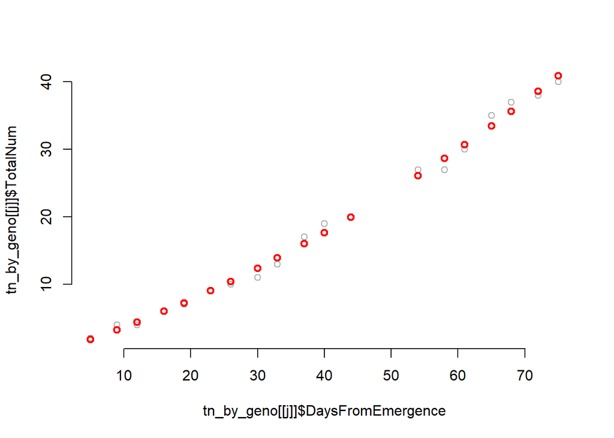

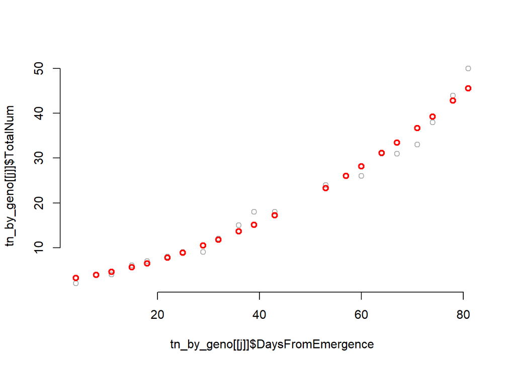

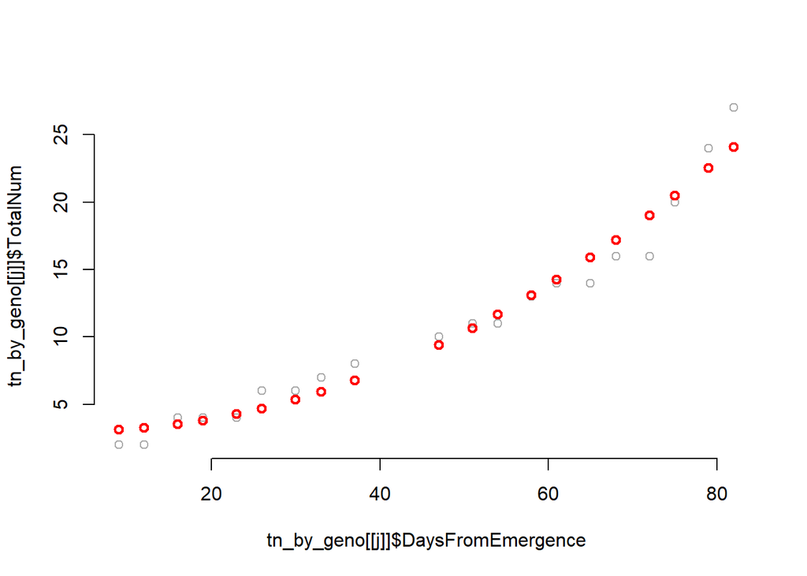

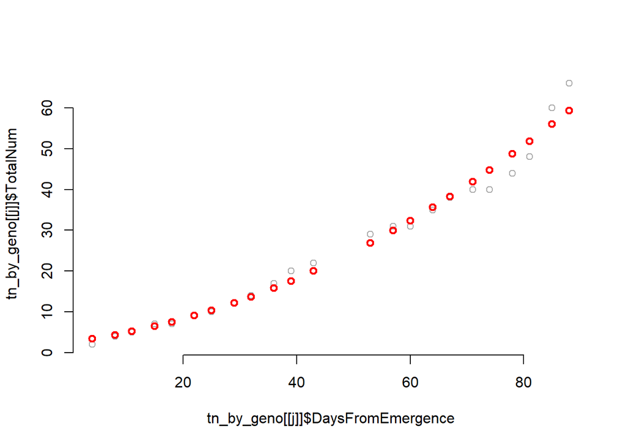

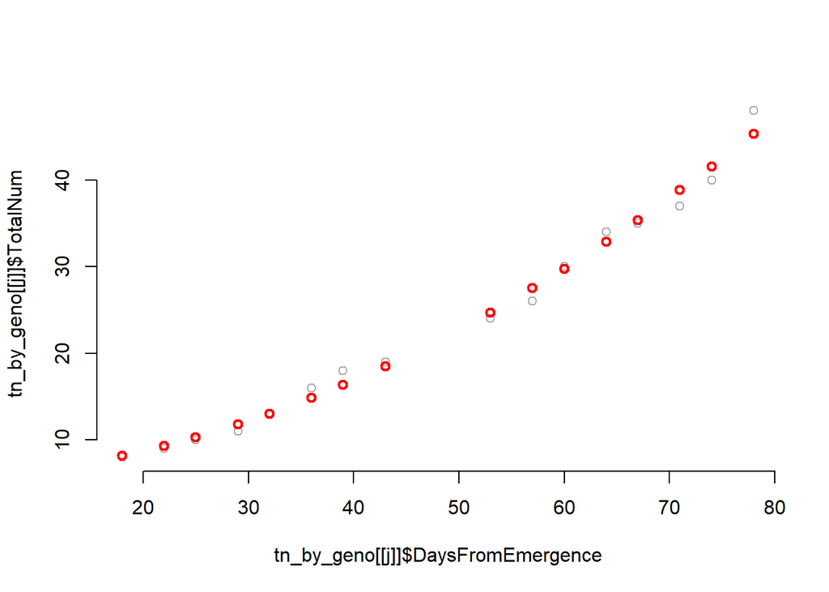

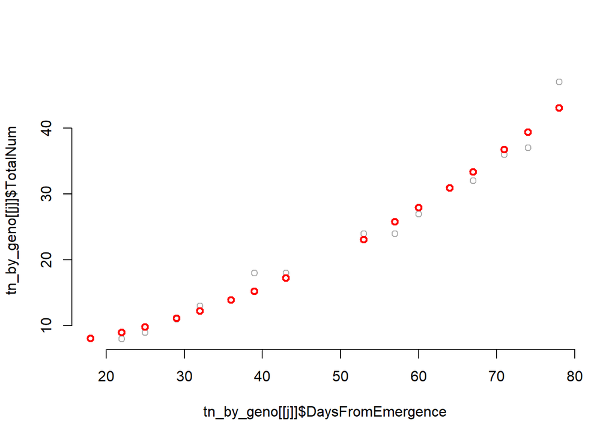

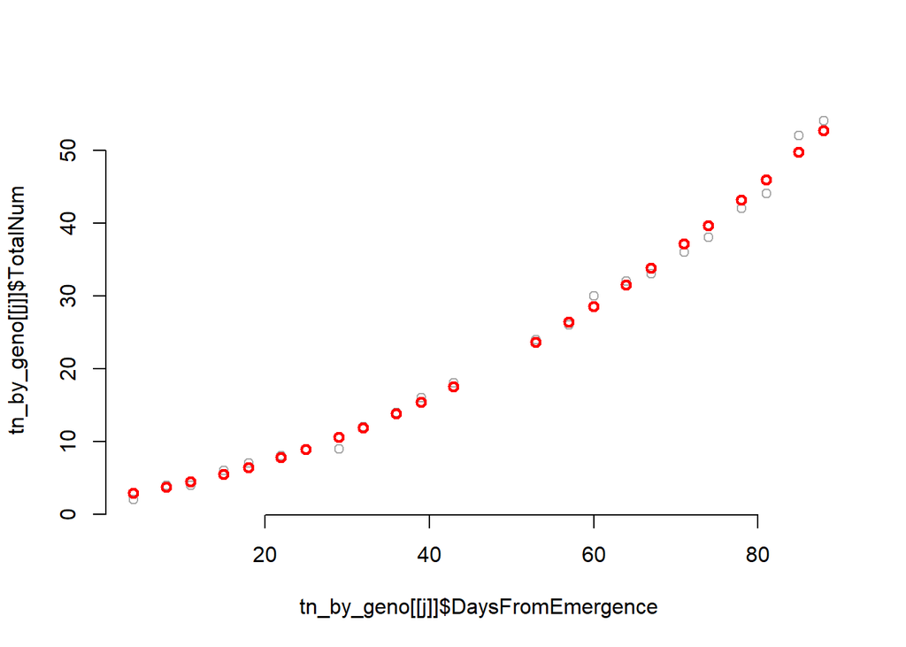

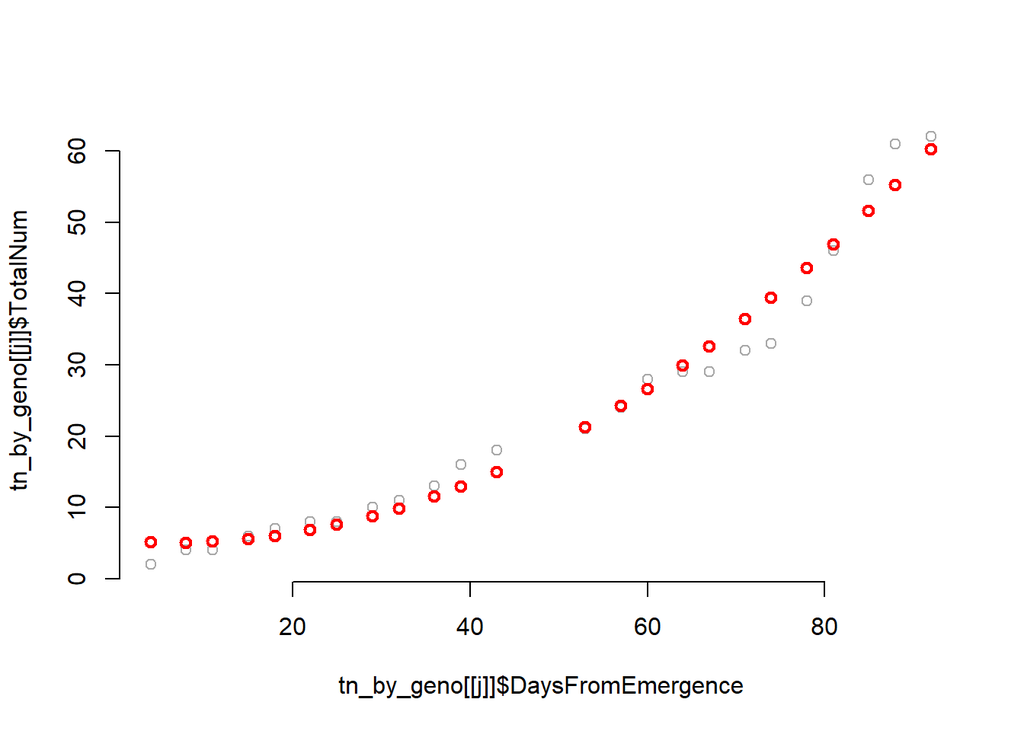

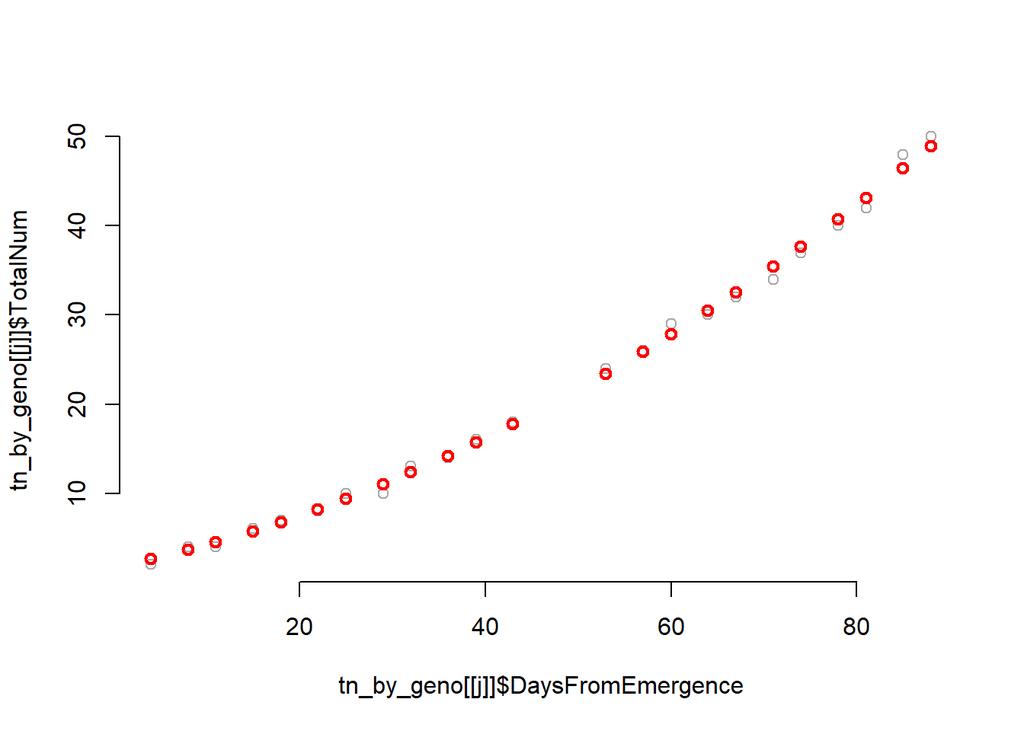

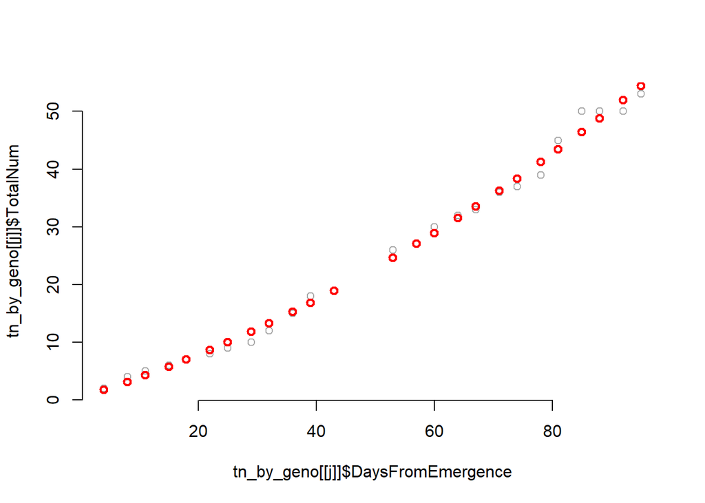

[30 more figures not shown]

```r
# run a model for each item in the area_by_geno list
slopes_tn <- data.frame(Geno = c(genos[c(1,3,4,6:22)], genos),
                     Trt = as.factor(c(rep("Cur", times = 20), rep("Fut", times = 22))),
                     Beta = rep(NA, times = 42))
slopes_tn$uniqueID <- paste0(slopes_tn$Trt, slopes_tn$Geno )
slopes_tn$Pop <- factor("SW", levels = c("SW", "IT"))
slopes_tn[as.numeric(slopes_tn$Geno) < 11, "Pop" ] <- "IT"

for (j in 1:length(tn_by_geno)){
  tmp <- lm(TotalNum ~ DaysFromEmergence, data = tn_by_geno[[j]])
  # do any of the models fit well?
  #hist(residuals(tmp))
  #plot(fitted(tmp), residuals(tmp, type = "pearson", scaled = TRUE))
  slopes_tn$Beta[j] <- tmp[["coefficients"]][["DaysFromEmergence"]]
  # model data
  #modData = tmp$coefficients[1]+tn_by_geno[[j]]$DaysFromEmergence*tmp$coefficients[2]
  ## look at the model-predicted data curve on top of the actual data
  #plot(tn_by_geno[[j]]$DaysFromEmergence, tn_by_geno[[j]]$TotalNum, bty="n", col="darkgray")
  #points(tn_by_geno[[j]]$DaysFromEmergence, modData,col="red",lwd=2)

}

# check quadratic
slopes2_tn <- data.frame(Geno = c(genos[c(1,3,4,6:22)], genos),
                     Trt = as.factor(c(rep("Cur", times = 20), rep("Fut", times = 22))),
                     Beta = rep(NA, times = 42),
                     gamma = rep(NA, times = 42))
slopes2_tn$uniqueID <- paste0(slopes_tn$Trt, slopes_tn$Geno )
slopes2_tn$Pop <- factor("SW", levels = c("SW", "IT"))
slopes2_tn[as.numeric(slopes2_tn$Geno) < 11, "Pop" ] <- "IT"

for (j in 1:length(tn_by_geno)){
  tmp <- lm(TotalNum ~ DaysFromEmergence + quad_date, data = tn_by_geno[[j]])
  # do any of the models fit well?
  #hist(residuals(tmp))
  #plot(fitted(tmp), residuals(tmp, type = "pearson", scaled = TRUE))
  slopes2_tn$Beta[j] <- tmp[["coefficients"]][["DaysFromEmergence"]]
  slopes2_tn$gamma[j] <- tmp[["coefficients"]][["quad_date"]]
  slopes2_tn$intercept[j] <- tmp[["coefficients"]][["(Intercept)"]]
  # model data
  modData = tmp$coefficients[1]+as.numeric(tn_by_geno[[j]]$DaysFromEmergence)*tmp$coefficients[2] + as.numeric(tn_by_geno[[j]]$quad_date)*tmp$coefficients[3]
  ## look at the model-predicted data curve on top of the actual data
  plot(tn_by_geno[[j]]$DaysFromEmergence, tn_by_geno[[j]]$TotalNum, bty="n", col="darkgray")
  points(tn_by_geno[[j]]$DaysFromEmergence, modData,col="red",lwd=2)

}
```

Now run the second model to look at differences by pop or trt on beta and gamma. Only doing the quadratic because that has been the better fit for the other two models as well.

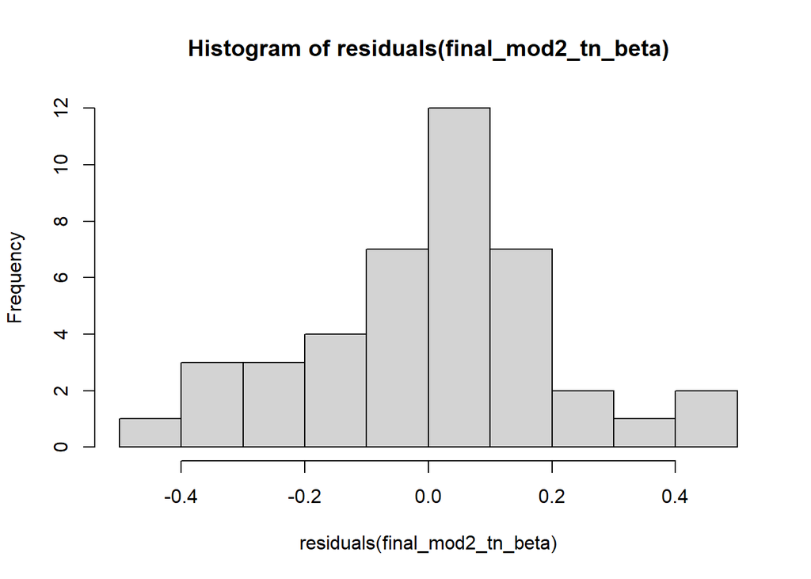

```r
final_mod2_tn_beta <- lm(Beta ~ Trt * Pop, data = slopes2_tn, contrasts = list(Trt=contr.sum, Pop = contr.sum))
hist(residuals(final_mod2_tn_beta))
```

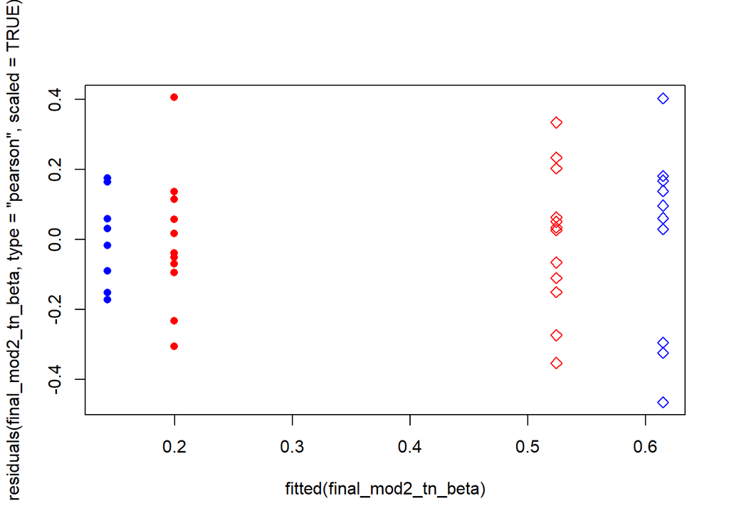

```r
plot(fitted(final_mod2_tn_beta), residuals(final_mod2_tn_beta, type = "pearson", scaled = TRUE),
       col = c("red", "blue")[as.numeric(slopes2_tn$Pop)],
       pch = c(16, 5)[as.numeric(slopes2_tn$Trt)])
```

```r
summary(final_mod2_tn_beta)
```

```
##
## Call:
## lm(formula = Beta ~ Trt * Pop, data = slopes2_tn, contrasts = list(Trt = contr.sum,
##     Pop = contr.sum))
##
## Residuals:
##      Min       1Q   Median       3Q      Max
## -0.46508 -0.10604  0.03063  0.13090  0.40614
##
## Coefficients:
##              Estimate Std. Error t value Pr(>|t|)
## (Intercept)  0.370359   0.032227  11.492 6.24e-14 ***
## Trt1        -0.199225   0.032227  -6.182 3.21e-07 ***
## Pop1        -0.008429   0.032227  -0.262    0.795
## Trt1:Pop1    0.036860   0.032227   1.144    0.260
## ---
## Signif. codes:  0 '***' 0.001 '**' 0.01 '*' 0.05 '.' 0.1 ' ' 1
##
## Residual standard error: 0.206 on 38 degrees of freedom
## Multiple R-squared:  0.5047, Adjusted R-squared:  0.4656
## F-statistic: 12.91 on 3 and 38 DF,  p-value: 5.821e-06
```

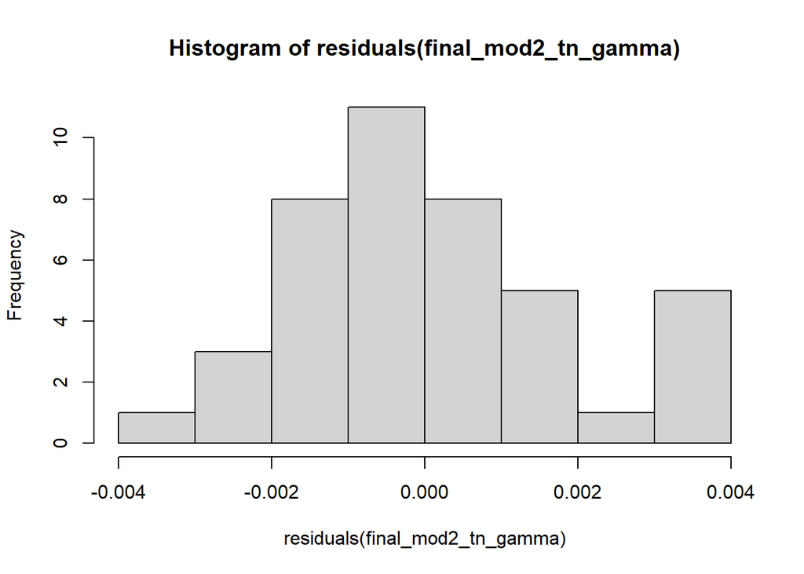

```r
# all the standard errors for each term are identical
final_mod2_tn_gamma <- lm(gamma ~ Trt * Pop, data = slopes2_tn, contrasts = list(Trt=contr.sum, Pop = contr.sum))
hist(residuals(final_mod2_tn_gamma))
```

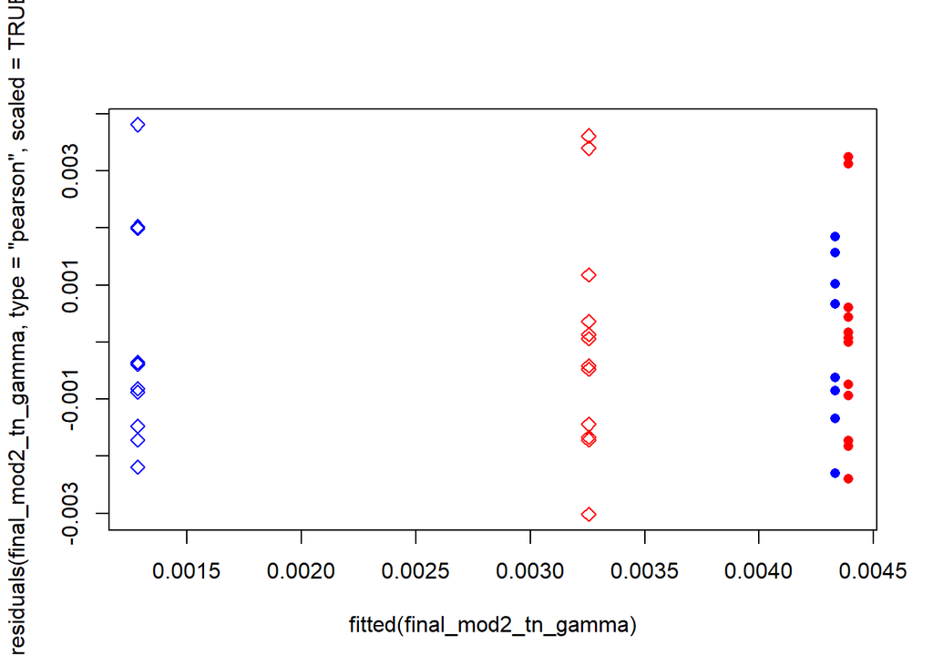

```r
plot(fitted(final_mod2_tn_gamma), residuals(final_mod2_tn_gamma, type = "pearson", scaled = TRUE),
       col = c("red", "blue")[as.numeric(slopes2_tn$Pop)],
       pch = c(16, 5)[as.numeric(slopes2_tn$Trt)])
```

```r
summary(final_mod2_tn_gamma)
```

```
##
## Call:
## lm(formula = gamma ~ Trt * Pop, data = slopes2_tn, contrasts = list(Trt = contr.sum,
##     Pop = contr.sum))
##
## Residuals:
##        Min         1Q     Median         3Q        Max
## -0.0030183 -0.0014141 -0.0003723  0.0009312  0.0038084
##
## Coefficients:
##               Estimate Std. Error t value Pr(>|t|)
## (Intercept)  0.0033155  0.0002865  11.573 5.06e-14 ***
## Trt1         0.0010460  0.0002865   3.651 0.000783 ***
## Pop1         0.0005065  0.0002865   1.768 0.085093 .
## Trt1:Pop1   -0.0004784  0.0002865  -1.670 0.103126
## ---
## Signif. codes:  0 '***' 0.001 '**' 0.01 '*' 0.05 '.' 0.1 ' ' 1
##
## Residual standard error: 0.001831 on 38 degrees of freedom
## Multiple R-squared:  0.3324, Adjusted R-squared:  0.2797
## F-statistic: 6.306 on 3 and 38 DF,  p-value: 0.001405
```

```r
final_mod2_tn_int <- lm(intercept ~ Trt * Pop, data = slopes2_tn, contrasts = list(Trt=contr.sum, Pop = contr.sum))

# estimated marginal means for plotting
slope2_tn_means <- as.data.frame(emmeans(final_mod2_tn_beta, specs = c("Trt", "Pop")))
slope2_tn_gammas <- as.data.frame(emmeans(final_mod2_tn_gamma, specs = c("Trt", "Pop")))
slope2_tn_intercepts <- as.data.frame(emmeans(final_mod2_tn_int, specs = c("Trt", "Pop")))

# plot
beta_totalnum <- ggplot(data = slopes2_tn, aes(y = Beta, x = Trt))+
  geom_point(aes(col = Pop, fill = Pop, shape = Pop), alpha = 0.6, position = position_jitter(width = .3, height = 0), size = 2)+
  geom_errorbar(data = slope2_tn_means, aes(x = Trt, y = emmean, ymin=lower.CL, ymax = upper.CL, col = Pop),position = position_dodge(width = 0.5), width = 0.3, size = 0.8, show.legend = FALSE)+
    geom_point(data = slope2_tn_means, aes(x = Trt, y = emmean, fill = Pop, shape = Pop),position = position_dodge(width = 0.5), size = 3)+ # big point for pop means
  labs(x = "Treatment")+
  scale_color_manual(name = "Population",
                     labels = c("Sweden", "Italy"),
                     values = c("#009E73", "#CC79A7"))+
  scale_fill_manual(name = "Population",
                     labels = c("Sweden", "Italy"),
                     values = c("#009E73", "#CC79A7"))+
    scale_shape_manual(name = "Population",
                     labels = c("Sweden", "Italy"),
                     values = c(24, 21))

gamma_totalnum <- ggplot(data = slopes2_tn, aes(y = gamma, x = Trt))+
  geom_point(aes(col = Pop, fill = Pop, shape = Pop), alpha = 0.6, position = position_jitter(width = .3, height = 0), size = 2)+
  geom_errorbar(data = slope2_tn_gammas, aes(x = Trt, y = emmean, ymin=lower.CL, ymax = upper.CL, col = Pop),position = position_dodge(width = 0.5), width = 0.3, size = 0.8, show.legend = FALSE)+
  geom_point(data = slope2_tn_gammas, aes(x = Trt, y = emmean, fill = Pop, shape = Pop),position = position_dodge(width = 0.5), size = 3)+ # big point for pop means
  labs(x = "Treatment", y = "Gamma")+
  scale_color_manual(name = "Population",
                     labels = c("Sweden", "Italy"),
                     values = c("#009E73", "#CC79A7"))+
  scale_fill_manual(name = "Population",
                     labels = c("Sweden", "Italy"),
                     values = c("#009E73", "#CC79A7"))+
    scale_shape_manual(name = "Population",
                     labels = c("Sweden", "Italy"),
                     values = c(24, 21))
```

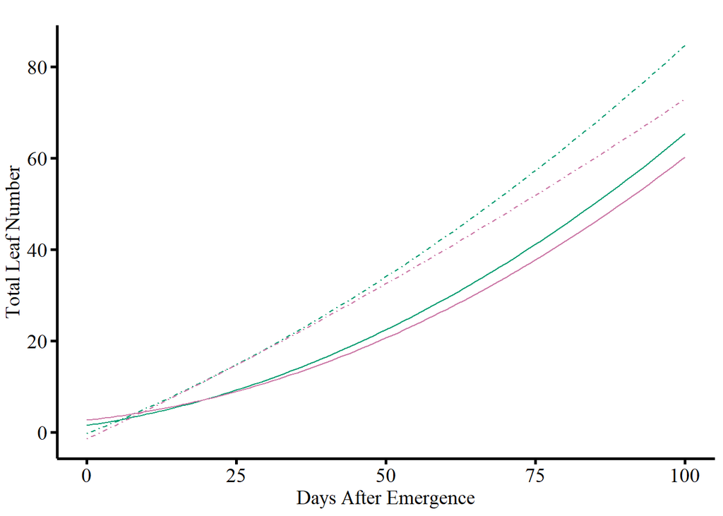

```r
trends_totalnum <- ggplot()+
  geom_function(fun = function(x) slope2_tn_intercepts$emmean[1] + slope2_tn_means$emmean[1]*x + slope2_tn_gammas$emmean[1]*x^2, colour = "#009E73", linetype = "solid", xlim=c(0, 100))+ # Cur SW
geom_function(fun = function(x) slope2_tn_intercepts$emmean[2] + slope2_tn_means$emmean[2]*x + slope2_tn_gammas$emmean[2]*x^2, colour = "#009E73", linetype = "dotdash", xlim=c(0, 100))+ # Fut SW
geom_function(fun = function(x) slope2_tn_intercepts$emmean[3] + slope2_tn_means$emmean[3]*x + slope2_tn_gammas$emmean[3]*x^2, colour = "#CC79A7", linetype = "solid", xlim=c(0, 100))+ # Cur IT
geom_function(fun = function(x) slope2_tn_intercepts$emmean[4] + slope2_tn_means$emmean[4]*x + slope2_tn_gammas$emmean[4]*x^2, colour = "#CC79A7", linetype = "dotdash", xlim=c(0, 100))+ # Fut IT
  labs(x = "Days After Emergence", y = "Total Leaf Number")

trends_totalnum
```

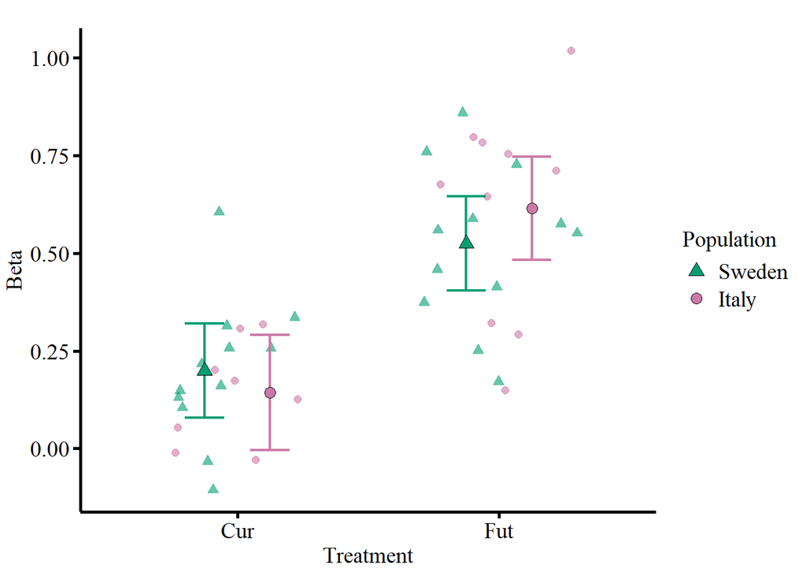

```r
beta_totalnum
```

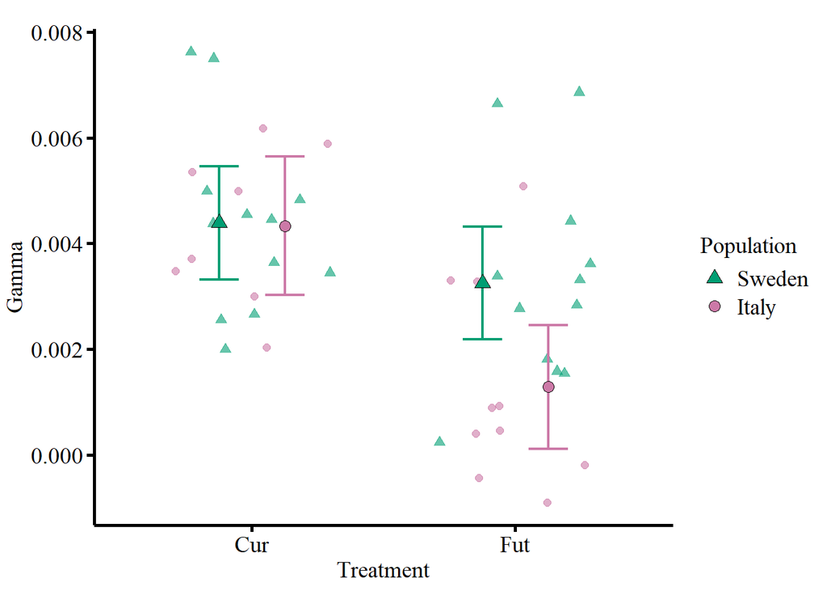

```r
gamma_totalnum
```

# Manuscript Plot

create multipanel figure for manuscript. This initially had all 3 traits but we decided on 7/16/2025 that we can cut total leaf number for simplicity to focus on rosette leaf number and rosette area .

```r
figure <- ggarrange(trends_leafarea+rremove("xlab"), beta_leafarea+rremove("xlab"), gamma_leafarea+rremove("xlab"),
                    trends_leafnum, beta_leafnum+rremove("xlab"), gamma_leafnum+rremove("xlab"),
          labels = c("A", "B", "C", "D", "E", "F", "G", "H", "I"),
          ncol = 3, nrow = 2,
          widths = c(1, 0.49, 0.51 ),
          common.legend = TRUE, # goes based on the first plot
          legend = "top",
          align = "hv")
# needs a 4:3 aspect ratio
ggsave(figure, filename = "../figures/Micropub_figure.jpg", width = 8, height = 6, units = "in", dpi = 500)
```

This figure is further edited in powerpoint to add statistical significance and a custom legend (exported below).

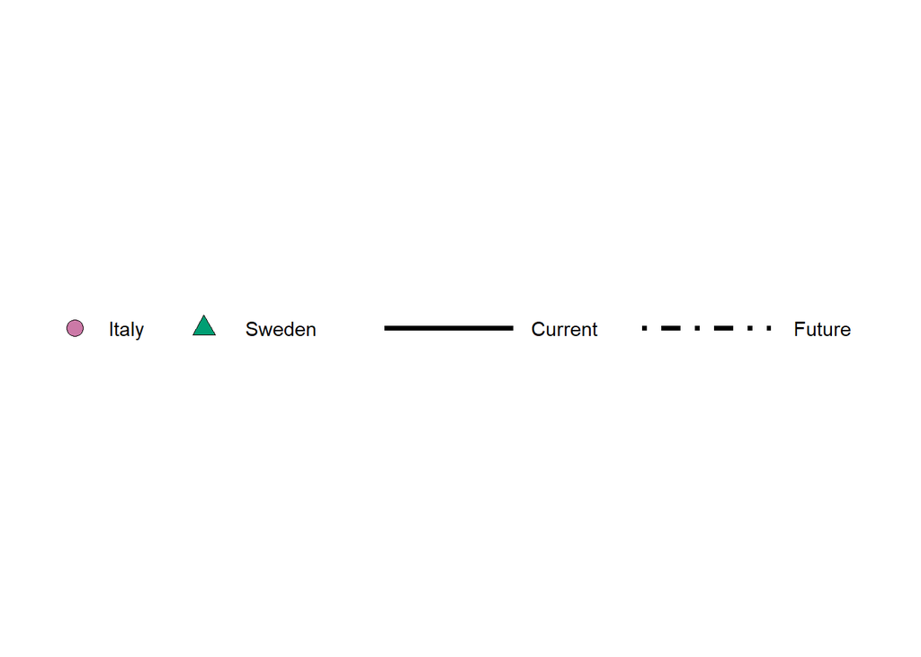

```r
# top legend
legend_points2 <- data.frame(xvals = c(1, 1.5), yvals = c(1, 1), text = c("Italy", "Sweden"), Pop = as.factor(c("IT", "SW")))
legend_fig <- ggplot()+
  geom_point(data = legend_points2, aes(x = xvals, y = yvals, fill = Pop, shape = Pop), size = 4, show.legend = FALSE)+
  geom_segment(aes(x = 2.2, y = 1, xend = 2.7, yend = 1), linetype = "solid", linewidth = 1.25)+
  geom_segment(aes(x = 3.2, y = 1, xend = 3.7, yend = 1), linetype = "dotdash", linewidth = 1.25)+
  geom_text(aes(x = c(1.2, 1.8, 2.9, 3.9), y = c(1, 1, 1, 1), label = c("Italy", "Sweden", "Current", "Future")))+
  scale_color_manual(name = "Population",
                     labels = c("IT", "SW"),
                     values = c("#CC79A7", "#009E73"))+
  scale_fill_manual(name = "Population",
                     labels = c("IT", "SW"),
                     values = c("#CC79A7", "#009E73"))+
  scale_shape_manual(name = "Population",
                     labels = c("Sweden", "Italy"),
                     values = c(21, 24))+
  xlim(c(0.87, 4.12))+
  theme_void()
legend_fig
```

```r
# for updating figure legend after
ggsave(legend_fig, filename = "../figures/legend.png", dpi = 500, width = 8, height = 0.5, units = "in")
```

# check correlation for manuscript

want to check correlation between traits to report in the manuscript

```r
check.cor <- merge(rosarea, rosnum, by = c("PotLabel", "Flat", "Pos", "Trt", "Geno", "Population", "grp", "EmergenceDate", "BoltingDate", "Date", "Date2", "DaysFromEmergence", "quad_date"), all = FALSE )
# there is a lot of measurements with different days (1427 obs when all = TRUE) but still 768 observations only counting days where both measured on the same day
cor.test(check.cor$LeafArea, check.cor$LeafNum) # r = 0.8566571, p<2.2e-16
```

```
##
##  Pearson's product-moment correlation
##
## data:  check.cor$LeafArea and check.cor$LeafNum
## t = 45.959, df = 766, p-value < 2.2e-16
## alternative hypothesis: true correlation is not equal to 0
## 95 percent confidence interval:
##  0.8366147 0.8744091
## sample estimates:
##       cor
## 0.8566571
```

```r
cor.test(check.cor$log_area, check.cor$LeafNum) # r = 0.8311089, p<2.2e-16
```

```
##
##  Pearson's product-moment correlation
##
## data:  check.cor$log_area and check.cor$LeafNum
## t = 41.363, df = 766, p-value < 2.2e-16
## alternative hypothesis: true correlation is not equal to 0
## 95 percent confidence interval:
##  0.8078640 0.8517722
## sample estimates:
##       cor
## 0.8311089
```